# Predicting High-Density Lipoprotein Cholesterol Levels

432 Project A: A Partial Demonstration

Author

Thomas E. Love, Ph.D.

Published

2025-02-11

## What is This?

This is a demonstration Project A for 432. It includes everything you **must** include in sections 1, 2, 4-9, and 11-13, although there are numerous places where a better project would say more about the results shown here than I have. I also have only performed single imputation, rather than multiple imputation, in this demonstration project, and I’ve only given some guidance regarding the discussion, leaving it up to you.

I decided to share this with students in the class in an effort to ensure that students could meet the minimum standards for the project (to obtain a solid B) more easily.

## R Packages and Setup

```r
knitr::opts_chunk$set(comment = NA)

library(janitor)
library(naniar)

library(broom)
library(car)
library(caret)
library(GGally)
library(gt)
library(gtsummary)
library(knitr)
library(mice)
library(mosaic)
library(patchwork)
library(ROCR)
library(rsample)
library(rms)

library(easystats)
library(tidyverse)

theme_set(theme_bw())
```

# 1 Data Source

These data come from the 2015-16 and 2017-18 administrations of the [National Health and Nutrition Examination Survey](https://www.cdc.gov/nchs/nhanes/index.htm) from the Centers for Disease Control and Prevention.

- The 2015-16 data are described in detail and accessed [here](https://wwwn.cdc.gov/nchs/nhanes/continuousnhanes/default.aspx?BeginYear=2015)
- The 2017-18 data are described in detail and accessed [here](https://wwwn.cdc.gov/nchs/nhanes/continuousnhanes/default.aspx?BeginYear=2017)

In each year, we gathered data from the Demographics (DEMO) files (DEMO_I and DEMO_J, respectively), the Body Measures (BMX) files, the Cholesterol - High Density Lipoprotein (HDL) files, and the Current Health Status (HSQ) files.

# 2 The Subjects

The NHANES files contain complete data on our linear regression outcome (HDL cholesterol level) and our logistic regression outcome (sex-dependent cutoff for “at risk” HDL cholesterol: < 40 mg/dl for men and < 50 mg/dl for women) for a total of 6203 subjects between the ages of 40 and 79. Our tidied tibble (for analyses) consists of a random sample of 999 of those subjects.

# 3 Loading and Tidying the Data

**Important**

Here I provide only a summary of the steps I took. In your project, you’ll actually have to show your data management work.

In building this document, I used the `nhanesA` package for R, which is not currently available on CRAN. In addition, the repository of NHANES materials at the CDC website has changed in some ways that don’t allow me to use my original code. So, I have created a file called `nh_demo.Rds` which contains the tidied version of my data.

## 3.1 How the `nh_demo` file was built

I included the following items, from both 2017-18 and 2015-16 NHANES.

From the DEMO files: [`DEMO_J` for 2017-18](https://wwwn.cdc.gov/Nchs/Nhanes/2017-2018/DEMO_J.htm) and [`DEMO_I` for 2015-16](https://wwwn.cdc.gov/Nchs/Nhanes/2015-2016/DEMO_I.htm)

- SEQN = Subject identifying code
- RIDSTATR = Interview/Examination Status (categorical)
  - 1 = Interview only
  - 2 = Interview and MEC examination (MEC = mobile examination center)
- RIDAGEYR = Age in years (quantitative, topcoded at 80)
  - All subjects ages 80 and over are coded as 80
- RIAGENDR = Sex (categorical)
  - 1 = Male, 2 = Female
- RIDRETH3 = Race/Ethnicity (categorical)
  - 1 = Mexican-American,
  - 2 = Other Hispanic (1 and 2 are often combined)
  - 3 = Non-Hispanic White
  - 4 = Non-Hispanic Black
  - 6 = Non-Hispanic Asian
  - 7 = Other Race including Multi-Racial
  - Note that categories 1 and 2 are often combined, and sometimes we leave out category 7, or combine it with 6.

From the Body Measures (BMX) files: [`BMX_J` for 2017-18](https://wwwn.cdc.gov/Nchs/Nhanes/2017-2018/BMX_J.htm) and [`BMX_I` for 2015-16](https://wwwn.cdc.gov/Nchs/Nhanes/2015-2016/BMX_I.htm) (BMX is part of the Examination data)

- BMXWAIST = Waist Circumference in cm (quantitative)

From the Cholesterol - High-Density Lipoprotein (HDL) files: [`HDL_J` for 2017-18](https://wwwn.cdc.gov/Nchs/Nhanes/2017-2018/HDL_J.htm) and [`HDL_I` for 2015-16](https://wwwn.cdc.gov/Nchs/Nhanes/2015-2016/HDL_I.htm) (HDL is part of the Lab data)

- LBDHDD = Direct HDL cholesterol in mg/dl (quantitative)

From the Current Health Status (HSQ) file [`HSQ_J` for 2017-18](https://wwwn.cdc.gov/Nchs/Nhanes/2017-2018/HSQ_J.htm) and [`HSQ_I` for 2015-16](https://wwwn.cdc.gov/Nchs/Nhanes/2015-2016/HSQ_I.htm) (HSQ is part of the Questionnaire data)

- HSD010 = Self-reported general health (categorical)
  - 1 = Excellent
  - 2 = Very good
  - 3 = Good
  - 4 = Fair
  - 5 = Poor
  - 7 = Refused
  - 9 = Don’t Know

## 3.2 Ingesting and Cleaning the NHANES data

I used functions from the `nhanesA` package to pull in the data from each necessary database using `nhanes()` and `translated = FALSE`, then used `zap_label()` to delete the labels, and converted to tibbles. Next, I used `inner_join()` to merge data within each NHANES cycle.

Next, I selected the 8 variables we need from the merged cycle-specific files, and converted each of the categorical variables to factors except the SEQN (subject code.) Then I added an indicator of the CYCLE (2015-16 or 2017-18) in which the data were drawn, and combined it all into one big tibble with `full_join()`.

Then I decided to restrict our work here to adult subjects between the ages of 40 and 79, in part to avoid the fact that NHANES classifies everyone over age 80 as `RIDAGEYR` = 80. So that involved filtering to those with RIDAGEYR > 39 and RIDAGEYR < 80.

We have three quantitative variables: age (`RIDAGEYR`), waist circumference (`BMXWAIST`) and HDL Cholesterol (`LBDHDD`), which I renamed to AGE, WAIST and HDL, respectively. The ranges (minimum and maximum) for Age, Waist Circumference and HDL Cholesterol all seem fairly plausible to me. Perhaps you know better, and please do use that knowledge. We do have several hundred missing values in the waist circumference and HDL cholesterol values that we will need to deal with after we sample the data.

In terms of categorical variables, I started by checking to see that everyone has `RIDSTATR` status 2, meaning they completed both the NHANES questionnaire and the NHANES examination. Since they do, I then made sure our `CYCLE` variable works to indicate the NHANES reporting CYCLE for each subject by running `tabyl(CYCLE, RIDSTATR)`.

Next, I changed RIAGENDR to `SEX` with values “M” and “F” as a factor. Another option would have been to use a 1/0 numeric variable to represent, for example FEMALE = 1 if the subject was reported as female and 0 if the subject was reported as male.

Next, I created `RACE_ETH` to replace `RIDRETH3`.

- I recoded the levels of the `RIDRETH3` variable to use short, understandable group names, using `mutate()` and `fct_recode()`, and
- Collapsed the first two categories (Mexican-American and Other Hispanic) into a single category, using `fct_recode()`, and
- Changed the variable name to `RACE_ETH` using `mutate()` and
- Sorted the resulting factor in order of their counts using `fct_infreq()`.

The most common `RACE_ETH` turns out to be Non-Hispanic White, followed by Hispanic, then Non-Hispanic Black, Non-Hispanic Asian and finally Other Race (including Multi-Racial.) We won’t collapse any further for now.

Next, I changed `HSD010` to `SROH`, as follows.

- Again, I recoded the levels of this categorical variable with `fct_recode()`
- I also renamed the variable SROH (which is an abbreviation for self-reported overall health) with `mutate()`. Always explain your abbreviations.
- I also converted the values 7 (Refused) and 9 (Don’t Know) to missing values with `na_if()`, then I used `droplevels()` to drop all of the now-unused levels in the factors I’m using.

## 3.3 Our outcomes

Our outcomes are each based on HDL cholesterol level. So I filtered the data for complete cases on that variable.

Next, I created a binary outcome for logistic regression, which is an indicator (taking the values 0 and 1) for an HDL cholesterol value that is “at risk” according to [these standards published on the Mayo Clinic site](https://www.mayoclinic.org/diseases-conditions/high-blood-cholesterol/in-depth/hdl-cholesterol/art-20046388), specifically, an adult male is considered to be at risk if their HDL < 40 mg/dl and an adult female is considered to be at risk if their HDL < 50 mg/dl.

Since we have complete data in `nh_demo_full` on HDL and SEX, I used that data to create the new variable `HDL_RISK` as shown below, then checked to see that this had worked properly:

```r
## this code chunk is not evaluated here - just showing you what I would do

nh_demo_full <- nh_demo_full |>
  mutate(HDL_RISK = case_when(
    SEX == "M" & HDL < 40 ~ 1,
    SEX == "F" & HDL < 50 ~ 1,
    .default = 0))

## check to see if this worked properly
nh_demo_full |> group_by(HDL_RISK, SEX) |>
  summarise(n = n(), min(HDL), max(HDL))
```

## 3.4 Arranging the Tibble and Sampling the Data

- We don’t need `RIDSTATR` any more because we’ve checked and see that all its values are 2, as needed.
- We’ve renamed some variables and replaced others with better versions.

Finally, I selected 999 observations from our working file, called the `nh_demo_full` tibble for use in our subsequent analyses, and this sample is called `nh_demo`. I have provided you with the `nh_demo.Rds` file, which I’m loading below.

```r
nh_demo <- read_rds("data/nh_demo.Rds")
```

# 4 The Tidy Tibble

## 4.1 Listing the Tibble

**Note**

If I ask you to print/list a tibble, part of the reason is to ensure that it actually *is* a tibble. A tibble will, as below, only print the first 10 rows.

```r
nh_demo
```

```
# A tibble: 999 × 9
   SEQN    HDL HDL_RISK   AGE RACE_ETH WAIST SROH      SEX   CYCLE
   <chr> <dbl>    <dbl> <dbl> <fct>    <dbl> <fct>     <chr> <chr>
 1 84842    48        0    50 Hispanic 101.  Good      M     2015-16
 2 92202   111        0    65 NH_Black  77   Fair      F     2015-16
 3 93010    46        1    63 NH_White  NA   Poor      F     2015-16
 4 93974    39        1    59 NH_White 111.  Good      M     2017-18
 5 96205    56        0    52 NH_Black  98   Good      M     2017-18
 6 95571    42        1    54 NH_White 104.  Good      F     2017-18
 7 99969    54        0    69 NH_Black 115.  Fair      M     2017-18
 8 89494    36        1    42 NH_Asian  98.1 <NA>      F     2015-16
 9 83887   101        0    51 NH_Black  74   Excellent F     2015-16
10 96908    48        1    73 Other    102   Good      F     2017-18
# ℹ 989 more rows
```

## 4.2 Size and Identifiers

Our analytic tibble, called `nh_demo`, has 999 rows (observations) on 9 columns (variables.) Our indicator variable is the SEQN, and we have a unique SEQN for each row in our data set, as the code below demonstrates.

```r
identical(nrow(nh_demo), n_distinct(nh_demo$SEQN))
```

```
[1] TRUE
```

## 4.3 Save The Tibble

I’ve already done this so I won’t do it again, but this is the code I would use to save the file.

**Note**

Note that I have set this code chunk to `eval: false` so that it will not actually do anything. I’m just showing you what I would do to save the Rds file to the data sub-directory of our R project. You should not use `eval: false` anywhere in your Project A.

```r
write_rds(nh_demo, "data/nh_demo.Rds")
```

# 5 The Code Book

I’ve chosen here to build a rather detailed codebook containing useful information describing the analytic sample, `nh_demo`. I’ve used numerous tools to help give a variety of summaries which may be helpful.

## 5.1 Five Key Statements

I suggest you begin your Project A codebook with five statements (like the ones shown below) to fix ideas about the sample size, the missingness, the outcomes and a statement about the roles for the other variables.

**Note**

If you look at the Quarto code that generated this document, you will see that I have used in-line coding to fill in the counts of subjects in statements 1 and 2. You should, too.

1. **Sample Size** The data in our complete `nh_demo` sample consist of 999 subjects from NHANES 2015-16 and NHANES 2017-18 between the ages of 40 and 79 in whom our outcome variables (`HDL` and `HDL_RISK`) were measured.
2. **Missingness** Of the 999 subjects, 912 have complete data on all variables listed below.
3. Our **outcome** variables are `HDL`, which is the subject’s serum HDL cholesterol measured in mg/dl for the linear regression, and `HDL_RISK`, which indicates whether or not the subject’s HDL cholesterol is at risk (too low) given their sex, for the logistic regression. There are no missing data in either of these outcomes.
4. Candidate **predictors** for my models include `AGE`, `WAIST`, `RACE_ETH` and `SROH`, (for both models) as well as `SEX` for the linear model.
5. The other variables contained in my tidy tibble are `SEQN` which is the subject identifying code, and `CYCLE` which identifies whether this subject was part of the 2015-16 or 2017-18 NHANES reporting cycle.

## 5.2 Describing the Variables (5 Tabs)

Variables included in the `nh_demo` data are summarized and described in five different ways in the panel below. Click on the tab that interests you to see results.

**Tip**

Please provide, at minimum, the variable descriptions list and the data_codebook() results here. You can include the others if you like.

**Definitions**

In addition to the brief descriptions (including units of measurement, where appropriate) in the table below, descriptions of the original NHANES variables which led to these are also discussed in Section 3.1.

| Variable | Description |
| --- | --- |
| `SEQN` | NHANES subject identifying code |
| `HDL` | HDL cholesterol in mg/dl (**outcome for our linear model**) |
| `HDL_RISK` | Does HDL put subject at risk? 1 (yes) if HDL < 40 for males or if HDL < 50 for females, otherwise 0 (**outcome for logistic model**) |
| `AGE` | Age in years, restricted to 40-79 here |
| `RACE_ETH` | Race-Ethnicity: five categories (NH_white, NH_Black, NH_Asian, Hispanic, Other) |
| `WAIST` | Waist circumference, in cm |
| `SROH` | Self-Reported Overall Health: five categories (Excellent, Very_Good, Good, Fair, Poor) |
| `SEX` | Biological Sex: either F or M |
| `CYCLE` | NHANES reporting cycle: either 2015-16 or 2017-18 |

**data_codebook()**

**Note**

The `data_codebook()` function comes from the `datawizard` package, which is part of the `easystats` ecosystem.

```r
data_codebook(nh_demo)
```

```
nh_demo (999 rows and 9 variables, 9 shown)

ID | Name     | Type        |  Missings |        Values |           N
---+----------+-------------+-----------+---------------+------------
1  | SEQN     | character   |  0 (0.0%) |        100012 |   1 ( 0.1%)
   |          |             |           |        100067 |   1 ( 0.1%)
   |          |             |           |        100112 |   1 ( 0.1%)
   |          |             |           |        100142 |   1 ( 0.1%)
   |          |             |           |        100145 |   1 ( 0.1%)
   |          |             |           |        100150 |   1 ( 0.1%)
   |          |             |           |        100167 |   1 ( 0.1%)
   |          |             |           |        100178 |   1 ( 0.1%)
   |          |             |           |        100191 |   1 ( 0.1%)
   |          |             |           |        100210 |   1 ( 0.1%)
   |          |             |           |         (...) |
---+----------+-------------+-----------+---------------+------------
2  | HDL      | numeric     |  0 (0.0%) |     [22, 149] |         999
---+----------+-------------+-----------+---------------+------------
3  | HDL_RISK | numeric     |  0 (0.0%) |             0 | 666 (66.7%)
   |          |             |           |             1 | 333 (33.3%)
---+----------+-------------+-----------+---------------+------------
4  | AGE      | numeric     |  0 (0.0%) |      [40, 79] |         999
---+----------+-------------+-----------+---------------+------------
5  | RACE_ETH | categorical |  0 (0.0%) |      NH_White | 333 (33.3%)
   |          |             |           |      Hispanic | 255 (25.5%)
   |          |             |           |      NH_Black | 229 (22.9%)
   |          |             |           |      NH_Asian | 145 (14.5%)
   |          |             |           |         Other |  37 ( 3.7%)
---+----------+-------------+-----------+---------------+------------
6  | WAIST    | numeric     | 44 (4.4%) | [66.5, 159.2] |         955
---+----------+-------------+-----------+---------------+------------
7  | SROH     | categorical | 56 (5.6%) |     Excellent |  84 ( 8.9%)
   |          |             |           |     Very_Good | 223 (23.6%)
   |          |             |           |          Good | 369 (39.1%)
   |          |             |           |          Fair | 231 (24.5%)
   |          |             |           |          Poor |  36 ( 3.8%)
---+----------+-------------+-----------+---------------+------------
8  | SEX      | character   |  0 (0.0%) |             F | 540 (54.1%)
   |          |             |           |             M | 459 (45.9%)
---+----------+-------------+-----------+---------------+------------
9  | CYCLE    | character   |  0 (0.0%) |       2015-16 | 475 (47.5%)
   |          |             |           |       2017-18 | 524 (52.5%)
---------------------------------------------------------------------
```

**describe()**

**Note**

The `describe()` function (and the `html()` function) used here come from the `Hmisc` package, developed by Frank Harrell and his colleagues.

```r
describe(nh_demo) |> html()
```

nh_demo  
9 Variables 999 Observations

SEQN

| n | missing | distinct |
| --- | --- | --- |
| 999 | 0 | 999 |

lowest : 100012 100067 100112 100142 100145 , highest: 99937 99945 99966 99969 99997

HDL

| n | missing | distinct | Info | Mean | pMedian | Gmd | .05 | .10 | .25 | .50 | .75 | .90 | .95 |
| --- | --- | --- | --- | --- | --- | --- | --- | --- | --- | --- | --- | --- | --- |
| 999 | 0 | 86 | 0.999 | 53.6 | 52.5 | 18.3 | 31 | 35 | 41 | 51 | 63 | 76 | 85 |

lowest : 22 23 24 25 26 , highest: 108 111 112 137 149

HDL_RISK

| n | missing | distinct | Info | Sum | Mean |
| --- | --- | --- | --- | --- | --- |
| 999 | 0 | 2 | 0.667 | 333 | 0.3333 |

AGE

| n | missing | distinct | Info | Mean | pMedian | Gmd | .05 | .10 | .25 | .50 | .75 | .90 | .95 |
| --- | --- | --- | --- | --- | --- | --- | --- | --- | --- | --- | --- | --- | --- |
| 999 | 0 | 40 | 0.999 | 58.01 | 58 | 12.03 | 42 | 44 | 50 | 58 | 66 | 73 | 75 |

lowest : 40 41 42 43 44 , highest: 75 76 77 78 79

RACE_ETH

| n | missing | distinct |
| --- | --- | --- |
| 999 | 0 | 5 |

```
 Value      NH_White Hispanic NH_Black NH_Asian    Other
 Frequency       333      255      229      145       37
 Proportion    0.333    0.255    0.229    0.145    0.037
```

WAIST

```
        n  missing distinct     Info     Mean  pMedian      Gmd      .05      .10
      955       44      482        1    102.7    102.1    18.05    77.27    82.40
      .25      .50      .75      .90      .95
    92.05   101.20   112.60   123.50   131.65
```

lowest : 66.5 67.9 68.7 69 70.3 , highest: 150.5 151 151.3 153.5 159.2

SROH

| n | missing | distinct |
| --- | --- | --- |
| 943 | 56 | 5 |

```
 Value      Excellent Very_Good      Good      Fair      Poor
 Frequency         84       223       369       231        36
 Proportion     0.089     0.236     0.391     0.245     0.038
```

SEX

| n | missing | distinct |
| --- | --- | --- |
| 999 | 0 | 2 |

```
 Value          F     M
 Frequency    540   459
 Proportion 0.541 0.459
```

CYCLE

| n | missing | distinct |
| --- | --- | --- |
| 999 | 0 | 2 |

```
 Value      2015-16 2017-18
 Frequency      475     524
 Proportion   0.475   0.525
```

**tbl_summary()**

**Note**

The `tbl_summary()` function used here comes from the `gtsummary` package. Note that missing values are listed as “Unknown” by default.

```r
tbl_summary(select(nh_demo, -SEQN),
        label = list(
            HDL = "HDL (HDL Cholesterol in mg/dl)",
            HDL_RISK = "HDL_RISK (HDL < 40 if Male, < 50 if Female)?",
            AGE = "AGE (in years)",
            WAIST = "WAIST (circumference in cm)",
            CYCLE = "CYCLE (NHANES reporting)",
            RACE_ETH = "RACE_ETH (Race/Ethnicity)",
            SROH = "SROH (Self-Reported Overall Health)"),
        stat = list( all_continuous() ~
                "{median} [{min} to {max}]" ))
```

| **Characteristic** | **N = 999**<sup>1</sup> |
| --- | --- |
| HDL (HDL Cholesterol in mg/dl) | 51 [22 to 149] |
| HDL_RISK (HDL < 40 if Male, < 50 if Female)? | 333 (33%) |
| AGE (in years) | 58 [40 to 79] |
| RACE_ETH (Race/Ethnicity) |  |
| NH_White | 333 (33%) |
| Hispanic | 255 (26%) |
| NH_Black | 229 (23%) |
| NH_Asian | 145 (15%) |
| Other | 37 (3.7%) |
| WAIST (circumference in cm) | 101 [67 to 159] |
| Unknown | 44 |
| SROH (Self-Reported Overall Health) |  |
| Excellent | 84 (8.9%) |
| Very_Good | 223 (24%) |
| Good | 369 (39%) |
| Fair | 231 (24%) |
| Poor | 36 (3.8%) |
| Unknown | 56 |
| SEX |  |
| F | 540 (54%) |
| M | 459 (46%) |
| CYCLE (NHANES reporting) |  |
| 2015-16 | 475 (48%) |
| 2017-18 | 524 (52%) |

<sup>1</sup> Median [Min to Max]; n (%)

**Missingness**

**Note**

These summaries come from the `naniar` package.

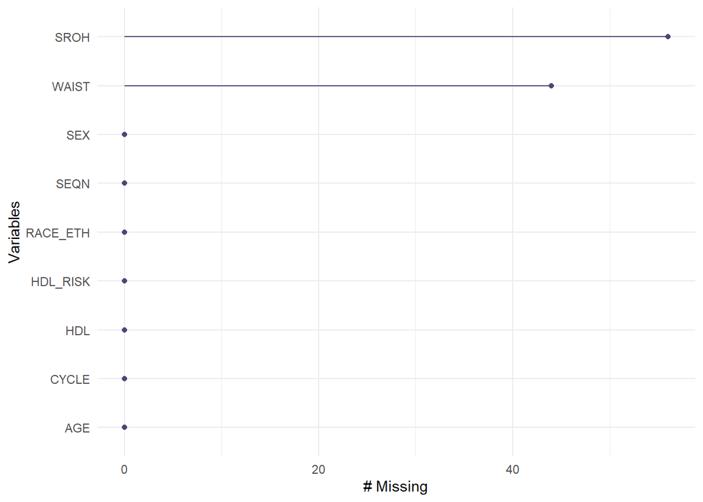

```r
gg_miss_var(nh_demo)
```

```r
miss_var_summary(nh_demo)
```

```
# A tibble: 9 × 3
  variable n_miss pct_miss
  <chr>     <int>    <num>
1 SROH         56     5.61
2 WAIST        44     4.40
3 SEQN          0     0
4 HDL           0     0
5 HDL_RISK      0     0
6 AGE           0     0
7 RACE_ETH      0     0
8 SEX           0     0
9 CYCLE         0     0
```

```r
miss_case_table(nh_demo)
```

```
# A tibble: 3 × 3
  n_miss_in_case n_cases pct_cases
           <int>   <int>     <dbl>
1              0     912     91.3
2              1      74      7.41
3              2      13      1.30
```

# 6 Linear Regression Plans

## 6.1 My First Research Question

How effectively can we predict HDL cholesterol levels using age, sex, race/ethnicity, waist circumference and self-reported overall health, in a sample of 999 NHANES participants ages 40-79?

## 6.2 My Quantitative Outcome

- My quantitative outcome is `HDL`, and I am interested in predicting this value using several more easily gathered characteristics of a subject.
- I have complete HDL data for all 999 subjects in my `nh_demo` tibble.

**Note**

Note that if for some reason I did not have complete data in my main tibble on this quantitative outcome, I would filter my data here to include only those cases with complete data on this linear model outcome, before preceding with the rest of section 6.

- My HDL data includes 86 different values, all measured in mg/dl.
- The distribution of HDL across the 999 subjects in my `nh_demo` data (shown in the Figure below) is a bit right skewed, with a median of 51, and ranging from 22 mg/dl to 149 mg/dl.

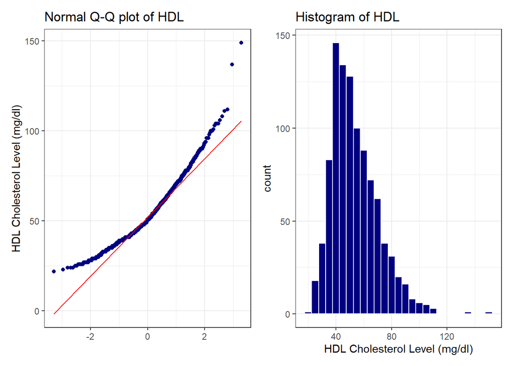

```r
p1 <- ggplot(nh_demo, aes(sample = HDL)) +
  geom_qq(col = "navy") + geom_qq_line(col = "red") +
  labs(title = "Normal Q-Q plot of HDL", x = "",
       y = "HDL Cholesterol Level (mg/dl)")

p2 <- ggplot(nh_demo, aes(x = HDL)) +
  geom_histogram(binwidth = 5, col = "white", fill = "navy") +
  labs(title = "Histogram of HDL", x = "HDL Cholesterol Level (mg/dl)")

p1 + p2
```

### 6.2.1 Numerical Summary of my linear outcome

**A new request**

This request is new. I want to see the following results for your outcome here, and if your main tibble includes some missing values of your linear outcome, again these should be filtered away in Section 6.

- The `Hmisc::describe()` results provide the number of observations, missing values (which should be 0 here) and the number of distinct values.
- The `mosaic::favstats()` results include the standard deviation, which is not in `Hmisc::describe()`.
- The `tabyl()` results show the five most common HDL values, so that you can check that none of them occur more than 10% of the time.
  - Dr. Love will let you use an outcome where one value exceeds 10% of your data, but only if it doesn’t exceed 20% of your data, and the second most common value doesn’t exceed 10% of your data.

Here are brief numerical summaries of my outcome.

```r
Hmisc::describe(nh_demo$HDL)
```

```
nh_demo$HDL
       n  missing distinct     Info     Mean  pMedian      Gmd      .05
     999        0       86    0.999     53.6     52.5     18.3       31
     .10      .25      .50      .75      .90      .95
      35       41       51       63       76       85

lowest :  22  23  24  25  26, highest: 108 111 112 137 149
```

```r
mosaic::favstats(nh_demo$HDL)
```

```
 min Q1 median Q3 max    mean       sd   n missing
  22 41     51 63 149 53.6046 16.69348 999       0
```

```r
nh_demo |> tabyl(HDL) |> adorn_pct_formatting() |> arrange(desc(n)) |> head(5)
```

```
 HDL  n percent
  41 48    4.8%
  48 37    3.7%
  43 30    3.0%
  45 30    3.0%
  49 29    2.9%
```

### 6.2.2 Summary Statements about my outcome, HDL.

My outcome is HDL.

- I have 999 observations and no missing values on HDL.
- I have 86 distinct HDL values.
- The range is 22 to 149, with mean 53.6 and standard deviation 16.7 mg/dl.
- The most common value for HDL is 41, which occurs in 4.8% of my subjects.

## 6.3 My Planned Predictors (Linear Model)

The predictors I intend to use in my linear model are `AGE` and `WAIST`, which are quantitative, `SEX`, which is a binary categorical variable, and `RACE_ETH` and `SROH`, each of which are 5-category variables treated as factors in my `nh_demo` tibble.

```r
nh_demo |> tabyl(RACE_ETH, SROH) |> adorn_totals(where = c("row", "col"))
```

```
 RACE_ETH Excellent Very_Good Good Fair Poor NA_ Total
 NH_White        25       101  121   62   14  10   333
 Hispanic        19        38   87   90    8  13   255
 NH_Black        13        46   95   58    7  10   229
 NH_Asian        25        32   48   16    3  21   145
    Other         2         6   18    5    4   2    37
    Total        84       223  369  231   36  56   999
```

### 6.3.1 Anticipated Direction of Effects

I expect Higher HDL to be associated with lower age, with lower waist circumference, with being female, with reporting better self-reported overall health, and with non-hispanic white ethnicity.

### 6.3.2 Missingness Summary

**A new request**

This request is also new. I want to see the following summary of missing values in your covariates here, after filtering to complete cases on your quantitative outcome variable.

I’m hoping that you’ll have complete data for all predictors on more than 60% of your observations, and that you won’t be missing more than 20% of any individual predictor.

Here is a report on missing data in my predictors for the linear model.

```r
linear_model_predictors <- nh_demo |> select(AGE, WAIST, SEX, RACE_ETH, SROH)

miss_var_summary(linear_model_predictors) |> filter(n_miss > 0)
```

```
# A tibble: 2 × 3
  variable n_miss pct_miss
  <chr>     <int>    <num>
1 SROH         56     5.61
2 WAIST        44     4.40
```

```r
miss_case_table(linear_model_predictors)
```

```
# A tibble: 3 × 3
  n_miss_in_case n_cases pct_cases
           <int>   <int>     <dbl>
1              0     912     91.3
2              1      74      7.41
3              2      13      1.30
```

- I have complete data for all linear model predictors in 912 (91.3%) of the 999 rows in my data.
- I am missing 56 values (5.6%) for SROH, and 44 values (4.4%) for WAIST.

# 7 Logistic Regression Plans

## 7.1 My Second Research Question

How effectively can we predict whether or not a subject’s HDL cholesterol level is at risk (too low) using age, race/ethnicity, waist circumference and self-reported overall health, in a sample of 999 NHANES participants ages 40-79?

## 7.2 My Binary Outcome

- My binary outcome is `HDL_RISK`, and I am interested in predicting this value using several more easily gathered characteristics of a subject.
- I have complete `HDL_RISK` data for all 999 subjects in my `nh_demo` tibble.

```r
nh_demo |> tabyl(HDL_RISK) |> adorn_pct_formatting()
```

```
 HDL_RISK   n percent
        0 666   66.7%
        1 333   33.3%
```

**Note**

Note that if for some reason I did not have complete data in my main tibble on this binary outcome, I would filter my data here to include only those cases with complete data on this logistic model outcome, before preceding with the rest of section 7. Then I would display the `tabyl()` above for my binary outcome.

## 7.3 My Planned Predictors (Logistic Model)

I am again using four of the five predictors I used in my linear model, specifically age, waist circumference, self-reported overall health and race/ethnicity.

- Note that I am not including `SEX` in this model (although I did in my linear model) because my binary outcome variable’s cutoff values are stratified by `SEX`.

I have 333 observations in my smaller outcome group (those at risk), and so I am permitted to have up to $4 + (333-100)/100 = 6.33$, rounded to 6 predictors, so I’m within the acceptable limit prescribed by the Project A instructions.

### 7.3.1 Anticipated Direction of Effects

I expect higher rates of HDL risk to be associated with higher age, with higher waist circumference, with reporting worse self-reported overall health, and with Hispanic or non-Hispanic Black ethnicity.

### 7.3.2 Missingness Summary

**A new request**

This request is also new. I want to see the following summary of missing values in your covariates here, after filtering to complete cases on your binary outcome variable.

I’m hoping that you’ll have complete data for all predictors on more than 60% of your observations, and that you won’t be missing more than 20% of any individual predictor.

Here is a report on missing data in my predictors for the logistic model.

```r
logistic_model_predictors <- nh_demo |> select(AGE, WAIST, RACE_ETH, SROH)

miss_var_summary(logistic_model_predictors) |> filter(n_miss > 0)
```

```
# A tibble: 2 × 3
  variable n_miss pct_miss
  <chr>     <int>    <num>
1 SROH         56     5.61
2 WAIST        44     4.40
```

```r
miss_case_table(logistic_model_predictors)
```

```
# A tibble: 3 × 3
  n_miss_in_case n_cases pct_cases
           <int>   <int>     <dbl>
1              0     912     91.3
2              1      74      7.41
3              2      13      1.30
```

- I have complete data for all of the logistic model predictors in 912 (91.3%) of the 999 rows in my data.
- I am missing 56 values (5.6%) for SROH, and 44 values (4.4%) for WAIST.

# 8 Linear Regression Analyses

## 8.1 Missingness

I will assume missing values are missing at random (MAR) in this work, and use single imputation for my analyses.

Here’s a table of missingness before imputation. I have missing data on two of my predictors, SROH and WAIST.

```r
miss_var_summary(nh_demo) |> filter(n_miss > 0)
```

```
# A tibble: 2 × 3
  variable n_miss pct_miss
  <chr>     <int>    <num>
1 SROH         56     5.61
2 WAIST        44     4.40
```

### 8.1.1 Single Imputation Approach

I’ll use the `mice` package to do my single imputation (`m = 1`), with a seed set to `432432`.

```r
nh_demo_i <-
  mice(nh_demo, m = 1, seed = 432432, print = FALSE) |>
  complete() |>
  tibble()
n_miss(nh_demo_i)
```

```
[1] 0
```

We needn’t fear logged events in this context.

## 8.2 Outcome Transformation

Let’s look at the Box-Cox results from the `car` package.

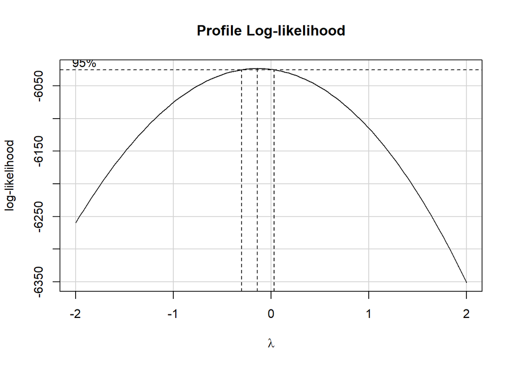

```r
mod_temp <- lm(HDL ~ AGE + SEX + RACE_ETH + WAIST + SROH, data = nh_demo_i)

boxCox(mod_temp)
```

The Box-Cox plot suggests that we take the logarithm of HDL before fitting our model, and so we shall. Here’s a plot of the distribution of the natural logarithm of HDL.

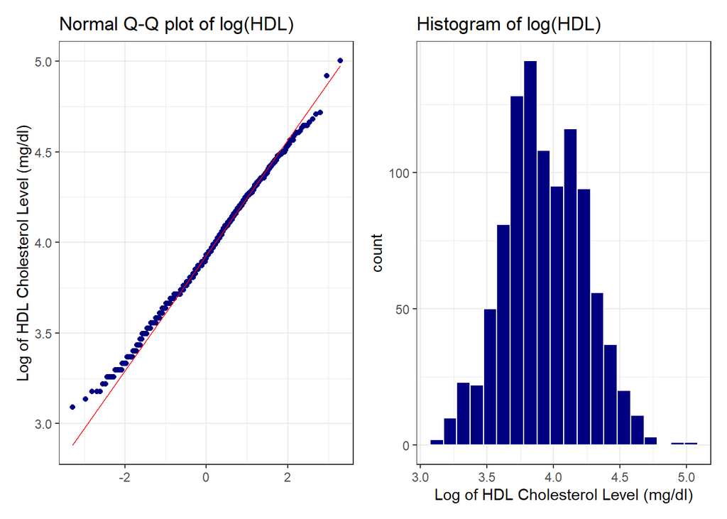

```r
nh_demo_i <- nh_demo_i |>
  mutate(logHDL = log(HDL))

p1 <- ggplot(nh_demo_i, aes(sample = logHDL)) +
  geom_qq(col = "navy") + geom_qq_line(col = "red") +
  labs(title = "Normal Q-Q plot of log(HDL)", x = "",
       y = "Log of HDL Cholesterol Level (mg/dl)")

p2 <- ggplot(nh_demo_i, aes(x = logHDL)) +
  geom_histogram(bins = 20, col = "white", fill = "navy") +
  labs(title = "Histogram of log(HDL)", x = "Log of HDL Cholesterol Level (mg/dl)")

p1 + p2
```

It does seem that this transformed outcome follows something closer to a Normal distribution.

## 8.3 Scatterplot Matrix and Collinearity

Here’s a scatterplot matrix of our outcome and predictors after transformation and imputation.

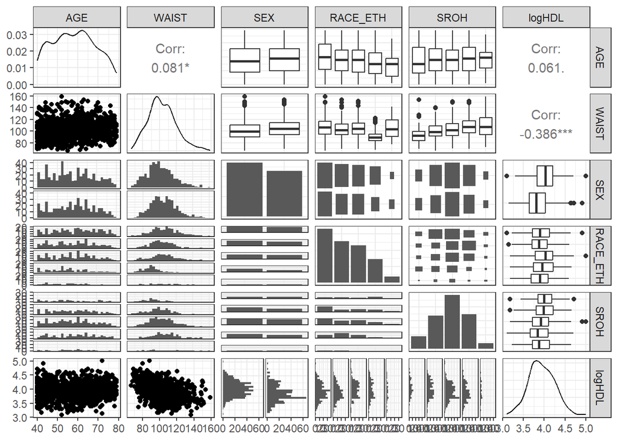

```r
ggpairs(nh_demo_i, columns = c("AGE", "WAIST", "SEX",
                               "RACE_ETH", "SROH", "logHDL"))
```

To check collinearity in more detail, we can estimate variance inflation factors for our predictors.

```r
mod_A <- lm(logHDL ~ AGE + SEX + RACE_ETH + WAIST + SROH, data = nh_demo_i)

car::vif(mod_A)
```

```
             GVIF Df GVIF^(1/(2*Df))
AGE      1.024684  1        1.012267
SEX      1.025596  1        1.012717
RACE_ETH 1.248667  4        1.028148
WAIST    1.233811  1        1.110770
SROH     1.182393  4        1.021163
```

We don’t have any large generalized VIF results here, so we have no meaningful concerns regarding collinearity.

## 8.4 Model A

### 8.4.1 Fitting Model A

Here is the fit using the `lm()` function.

```r
mod_A <- lm(logHDL ~ AGE + SEX + RACE_ETH + WAIST + SROH, data = nh_demo_i)
```

We’ll also fit model A with the `ols()` function from the `rms` package, even though we won’t actually use this fit for a while.

```r
dd <- datadist(nh_demo_i)
options(datadist = "dd")

mod_A_ols <- ols(logHDL ~ AGE + SEX + RACE_ETH + WAIST + SROH,
                 data = nh_demo_i, x = TRUE, y = TRUE)
```

### 8.4.2 Coefficient Estimates

**Note**

I’ll show two different approaches (`model_parameters()` from the `easystats` ecosystem, and `tidy()` from the `broom` package) to summarize the coefficient estimates from `mod_A`. Either is sufficient for Project A, and there’s no need to show both approaches.

**Model Parameters (Model A)**

```r
model_parameters(mod_A, ci = 0.90) |> print_md(digits = 3)
```

| Parameter | Coefficient | SE | 90% CI | t(987) | p |
| --- | --- | --- | --- | --- | --- |
| (Intercept) | 4.616 | 0.078 | (4.489, 4.744) | 59.436 | < .001 |
| AGE | 0.003 | 7.938e-04 | (0.001, 0.004) | 3.510 | < .001 |
| SEX (M) | -0.166 | 0.017 | (-0.194, -0.139) | -10.010 | < .001 |
| RACE ETH (Hispanic) | -0.042 | 0.022 | (-0.078, -0.005) | -1.873 | 0.061 |
| RACE ETH (NH_Black) | 0.090 | 0.022 | (0.053, 0.127) | 4.025 | < .001 |
| RACE ETH (NH_Asian) | -0.068 | 0.028 | (-0.114, -0.023) | -2.479 | 0.013 |
| RACE ETH (Other) | 0.013 | 0.045 | (-0.062, 0.088) | 0.289 | 0.773 |
| WAIST | -0.007 | 5.665e-04 | (-0.008, -0.006) | -12.257 | < .001 |
| SROH (Very_Good) | -0.008 | 0.032 | (-0.061, 0.045) | -0.243 | 0.808 |
| SROH (Good) | -0.074 | 0.031 | (-0.125, -0.023) | -2.392 | 0.017 |
| SROH (Fair) | -0.088 | 0.033 | (-0.143, -0.033) | -2.640 | 0.008 |
| SROH (Poor) | -0.023 | 0.050 | (-0.106, 0.059) | -0.466 | 0.642 |

**Tidied Coefficient Estimates (Model A)**

```r
tidy(mod_A, conf.int = TRUE, conf.level = 0.90) |>
  select(term, estimate, se = std.error, low90 = conf.low,
         high90 = conf.high, p = p.value) |>
  kable(digits = 3)
```

| term | estimate | se | low90 | high90 | p |
| --- | --- | --- | --- | --- | --- |
| (Intercept) | 4.616 | 0.078 | 4.489 | 4.744 | 0.000 |
| AGE | 0.003 | 0.001 | 0.001 | 0.004 | 0.000 |
| SEXM | -0.166 | 0.017 | -0.194 | -0.139 | 0.000 |
| RACE_ETHHispanic | -0.042 | 0.022 | -0.078 | -0.005 | 0.061 |
| RACE_ETHNH_Black | 0.090 | 0.022 | 0.053 | 0.127 | 0.000 |
| RACE_ETHNH_Asian | -0.068 | 0.028 | -0.114 | -0.023 | 0.013 |
| RACE_ETHOther | 0.013 | 0.045 | -0.062 | 0.088 | 0.773 |
| WAIST | -0.007 | 0.001 | -0.008 | -0.006 | 0.000 |
| SROHVery_Good | -0.008 | 0.032 | -0.061 | 0.045 | 0.808 |
| SROHGood | -0.074 | 0.031 | -0.125 | -0.023 | 0.017 |
| SROHFair | -0.088 | 0.033 | -0.143 | -0.033 | 0.008 |
| SROHPoor | -0.023 | 0.050 | -0.106 | 0.059 | 0.642 |

### 8.4.3 Model A Effects

Since we’ve built the `mod_A_ols` model using the `rms` package, it can be helpful to look at the effects using its plot and associated table, as shown below.

**Note**

If you look at the Quarto code, you’ll see that I’ve used `warning: false` in this code chunk to suppress some un-interesting warnings here, and in several other code chunks in this document. I encourage you to do the same in your Project A, for the code chunks that I’ve used `warning: false` in this demo.

- **Don’t** use `warning: false` otherwise in Project A, though.

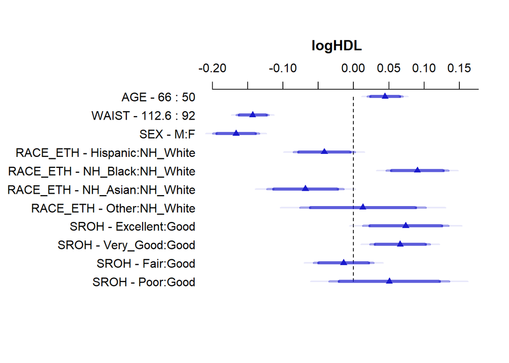

```r
plot(summary(mod_A_ols, conf.int = 0.90))
```

```r
summary(mod_A_ols, conf.int = 0.90) |> kable(digits = 3)
```

|  | Low | High | Diff. | Effect | S.E. | Lower 0.9 | Upper 0.9 | Type |
| --- | --- | --- | --- | --- | --- | --- | --- | --- |
| AGE | 50 | 66.0 | 16.0 | 0.045 | 0.013 | 0.024 | 0.065 | 1 |
| WAIST | 92 | 112.6 | 20.6 | -0.143 | 0.012 | -0.162 | -0.124 | 1 |
| SEX - M:F | 1 | 2.0 | NA | -0.166 | 0.017 | -0.194 | -0.139 | 1 |
| RACE_ETH - Hispanic:NH_White | 1 | 2.0 | NA | -0.042 | 0.022 | -0.078 | -0.005 | 1 |
| RACE_ETH - NH_Black:NH_White | 1 | 3.0 | NA | 0.090 | 0.022 | 0.053 | 0.127 | 1 |
| RACE_ETH - NH_Asian:NH_White | 1 | 4.0 | NA | -0.068 | 0.028 | -0.114 | -0.023 | 1 |
| RACE_ETH - Other:NH_White | 1 | 5.0 | NA | 0.013 | 0.045 | -0.062 | 0.088 | 1 |
| SROH - Excellent:Good | 3 | 1.0 | NA | 0.074 | 0.031 | 0.023 | 0.125 | 1 |
| SROH - Very_Good:Good | 3 | 2.0 | NA | 0.066 | 0.022 | 0.030 | 0.102 | 1 |
| SROH - Fair:Good | 3 | 4.0 | NA | -0.014 | 0.022 | -0.050 | 0.021 | 1 |
| SROH - Poor:Good | 3 | 5.0 | NA | 0.050 | 0.043 | -0.021 | 0.122 | 1 |

### 8.4.4 Quality of Fit Summaries

**Note**

I’ll show two different approaches (`model_performance()` from the `easystats` ecosystem, and `glance()` from the `broom` package) to summarize the quality of fit measures describing `mod_A`. I actually like being able to see both of these approaches, since each provides some unique information, so I would encourage you, too, to include both in your Project A.

**Model A Performance**

```r
model_performance(mod_A) |> print_md(digits = 3)
```

Indices of model performance

| AIC | AICc | BIC | R2 | R2 (adj.) | RMSE | Sigma |
| --- | --- | --- | --- | --- | --- | --- |
| 146.355 | 146.724 | 210.143 | 0.273 | 0.265 | 0.257 | 0.259 |

**Model A at a glance()**

In our Model A, we use 11 degrees of freedom, and obtain an $R^2$ value of 0.273.

```r
glance(mod_A) |>
  select(r2 = r.squared, adjr2 = adj.r.squared, sigma,
         AIC, BIC, nobs, df, df.residual) |>
  kable(digits = c(3, 3, 2, 1, 1, 0, 0, 0))
```

| r2 | adjr2 | sigma | AIC | BIC | nobs | df | df.residual |
| --- | --- | --- | --- | --- | --- | --- | --- |
| 0.273 | 0.265 | 0.26 | 146.4 | 210.1 | 999 | 11 | 987 |

### 8.4.5 Regression Diagnostics for Model A

**Note**

Note in the Quarto code for the next chunk that I have set the fig-height to 9, so that the plots are easier to read. Please do that, too, whenever you use `check_model()` from the `easystats` ecosystem.

- I also prefer that you run `check_model()` with `detrend = FALSE` for the Normal Q-Q plot of residuals, as done here.

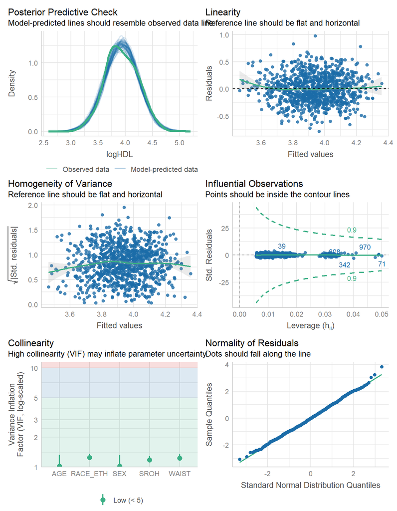

```r
check_model(mod_A, detrend = FALSE)
```

For the most part, these plots look very reasonable. I see no clear problems with the assumptions of linearity, normality or constant variance evident in any of these results.

The main issue is the posterior predictive check, where our predictions are missing near the center of the distribution a bit, with more predicted values of `log(HDL)` in the 3.75 to 4.25 range than we see in the original data.

## 8.5 Non-Linearity and Spearman $\rho^2$

Here’s the relevant Spearman $\rho^2$ plot, as a place to look for sensible places to consider a non-linear term or terms.

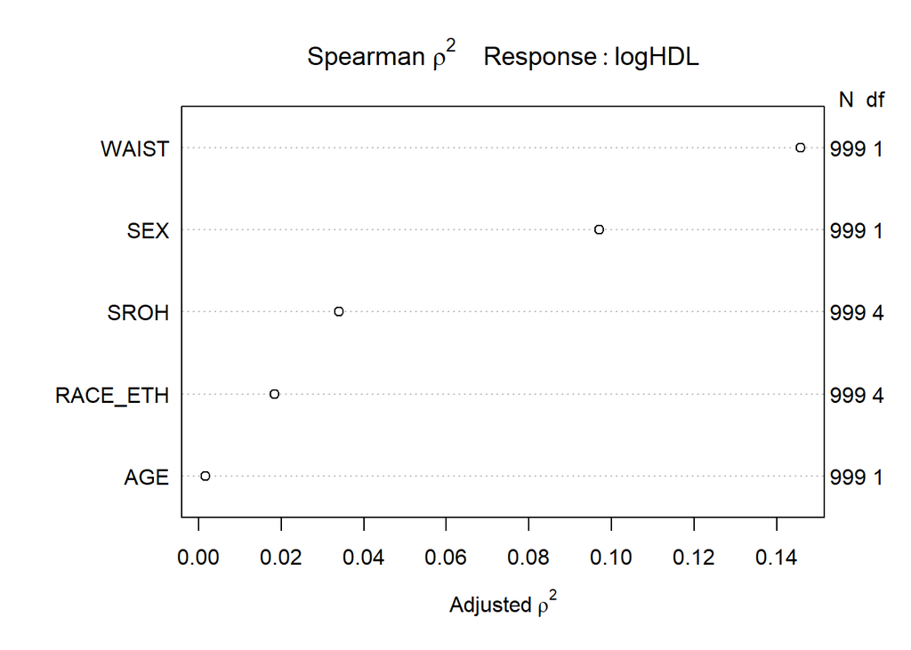

```r
plot(spearman2(logHDL ~ AGE + WAIST + SEX + RACE_ETH + SROH,
               data = nh_demo_i))
```

Our Spearman $\rho^2$ plot first suggests the use of a non-linear term in WAIST, so we’ll add a restricted cubic spline in WAIST using 5 knots, which should add 3 degrees of freedom to our initial model.

Next, the SEX variable also seems to be a good choice, so we’ll add an interaction between SEX and the main effect of WAIST, which will add one more degree of freedom to our model A.

## 8.6 Model B

Our Model B will add two non-linear terms, summing up to 4 additional degrees of freedom, to our Model A.

### 8.6.1 Fitting Model B

```r
mod_B <- lm(logHDL ~ AGE + rcs(WAIST, 5) + SEX +
              WAIST %ia% SEX + RACE_ETH + SROH,
            data = nh_demo_i)
```

We’ll also fit model B with the `ols()` function from the **rms** package.

```r
dd <- datadist(nh_demo_i)
options(datadist = "dd")

mod_B_ols <- ols(logHDL ~ AGE + rcs(WAIST, 5) + SEX +
              WAIST %ia% SEX + RACE_ETH + SROH,
            data = nh_demo_i, x = TRUE, y = TRUE)
```

### 8.6.2 Coefficient Estimates

**Note**

I’ll show two different approaches (`model_parameters()` from the `easystats` ecosystem, and `tidy()` from the `broom` package) to summarize the coefficient estimates from `mod_B`. Either is sufficient for Project A, and there’s no need to show both approaches. The `tidy()` approach handles the non-linear terms a bit better in my view, so I’d probably go with that.

**Model Parameters (Model B)**

```r
model_parameters(mod_B, ci = 0.90) |> print_md(digits = 3)
```

| Parameter | Coefficient | SE | 90% CI | t(983) | p |
| --- | --- | --- | --- | --- | --- |
| (Intercept) | 5.436 | 0.252 | (5.021, 5.852) | 21.549 | < .001 |
| AGE | 0.003 | 7.920e-04 | (0.002, 0.005) | 4.096 | < .001 |
| rcs(WAIST ( degree) | -0.017 | 0.003 | (-0.022, -0.012) | -5.617 | < .001 |
| rcs(WAIST ( degree) | 0.039 | 0.018 | (0.009, 0.068) | 2.151 | 0.032 |
| rcs(WAIST ( degree) | -0.158 | 0.095 | (-0.314, -0.001) | -1.661 | 0.097 |
| rcs(WAIST ( degree) | 0.188 | 0.132 | (-0.030, 0.406) | 1.422 | 0.155 |
| SEX (M) | -0.107 | 0.111 | (-0.291, 0.076) | -0.961 | 0.337 |
| WAIST %ia% SEX | -5.032e-04 | 0.001 | (-0.002, 0.001) | -0.473 | 0.637 |
| RACE ETH (Hispanic) | -0.034 | 0.022 | (-0.070, 0.002) | -1.548 | 0.122 |
| RACE ETH (NH_Black) | 0.088 | 0.022 | (0.051, 0.125) | 3.911 | < .001 |
| RACE ETH (NH_Asian) | -0.075 | 0.028 | (-0.121, -0.030) | -2.735 | 0.006 |
| RACE ETH (Other) | 0.010 | 0.045 | (-0.064, 0.084) | 0.223 | 0.823 |
| SROH (Very_Good) | -0.001 | 0.032 | (-0.055, 0.052) | -0.045 | 0.964 |
| SROH (Good) | -0.063 | 0.031 | (-0.114, -0.013) | -2.068 | 0.039 |
| SROH (Fair) | -0.087 | 0.033 | (-0.142, -0.033) | -2.638 | 0.008 |
| SROH (Poor) | -0.031 | 0.050 | (-0.113, 0.051) | -0.627 | 0.531 |

**Tidied Coefficient Estimates (Model B)**

```r
tidy(mod_B, conf.int = TRUE, conf.level = 0.90) |>
  select(term, estimate, se = std.error,
         low90 = conf.low, high90 = conf.high,
         p = p.value) |>
  kable(digits = 3)
```

| term | estimate | se | low90 | high90 | p |
| --- | --- | --- | --- | --- | --- |
| (Intercept) | 5.436 | 0.252 | 5.021 | 5.852 | 0.000 |
| AGE | 0.003 | 0.001 | 0.002 | 0.005 | 0.000 |
| rcs(WAIST, 5)WAIST | -0.017 | 0.003 | -0.022 | -0.012 | 0.000 |
| rcs(WAIST, 5)WAIST’ | 0.039 | 0.018 | 0.009 | 0.068 | 0.032 |
| rcs(WAIST, 5)WAIST’’ | -0.158 | 0.095 | -0.314 | -0.001 | 0.097 |
| rcs(WAIST, 5)WAIST’’’ | 0.188 | 0.132 | -0.030 | 0.406 | 0.155 |
| SEXM | -0.107 | 0.111 | -0.291 | 0.076 | 0.337 |
| WAIST %ia% SEX | -0.001 | 0.001 | -0.002 | 0.001 | 0.637 |
| RACE_ETHHispanic | -0.034 | 0.022 | -0.070 | 0.002 | 0.122 |
| RACE_ETHNH_Black | 0.088 | 0.022 | 0.051 | 0.125 | 0.000 |
| RACE_ETHNH_Asian | -0.075 | 0.028 | -0.121 | -0.030 | 0.006 |
| RACE_ETHOther | 0.010 | 0.045 | -0.064 | 0.084 | 0.823 |
| SROHVery_Good | -0.001 | 0.032 | -0.055 | 0.052 | 0.964 |
| SROHGood | -0.063 | 0.031 | -0.114 | -0.013 | 0.039 |
| SROHFair | -0.087 | 0.033 | -0.142 | -0.033 | 0.008 |
| SROHPoor | -0.031 | 0.050 | -0.113 | 0.051 | 0.531 |

### 8.6.3 Model B Effects

Here, we use the `mod_B_ols` model to look at the effects using its plot and associated table, which may be especially helpful when we include non-linear terms.

**Note**

I’ve used `warning: false` in this code chunk to suppress some un-interesting warnings. You can (for this type of plot) too, if you need to, in your Project A.

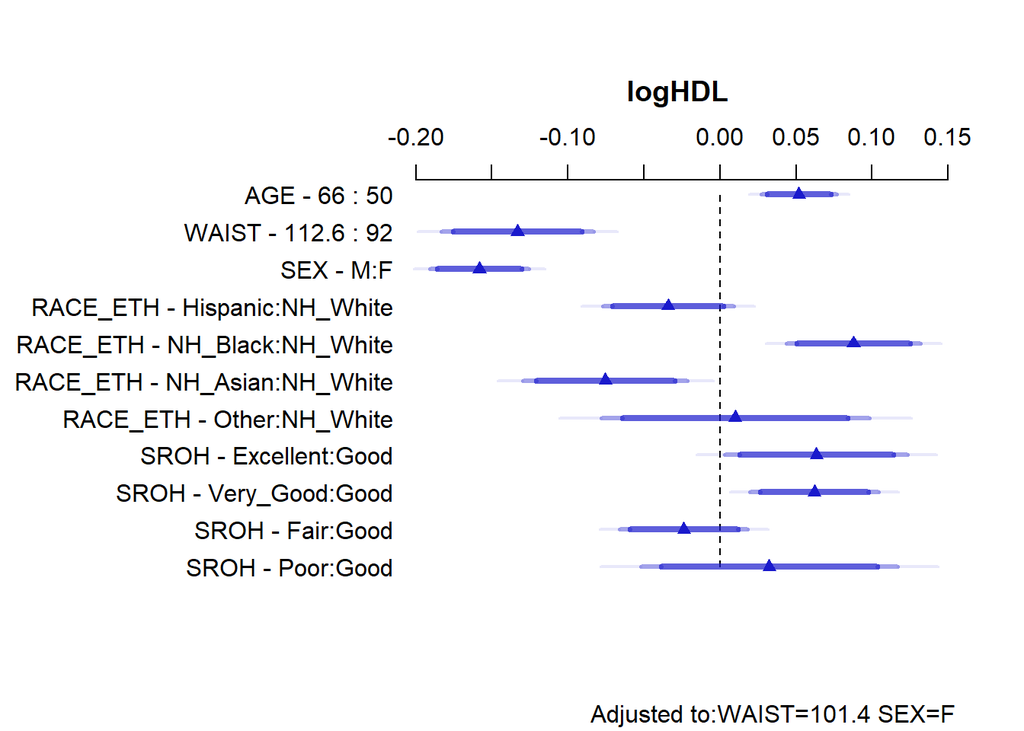

```r
plot(summary(mod_B_ols, conf.int = 0.90))
```

```r
summary(mod_B_ols, conf.int = 0.90) |> kable(digits = 3)
```

|  | Low | High | Diff. | Effect | S.E. | Lower 0.9 | Upper 0.9 | Type |
| --- | --- | --- | --- | --- | --- | --- | --- | --- |
| AGE | 50 | 66.0 | 16.0 | 0.052 | 0.013 | 0.031 | 0.073 | 1 |
| WAIST | 92 | 112.6 | 20.6 | -0.133 | 0.026 | -0.175 | -0.091 | 1 |
| SEX - M:F | 1 | 2.0 | NA | -0.158 | 0.017 | -0.186 | -0.131 | 1 |
| RACE_ETH - Hispanic:NH_White | 1 | 2.0 | NA | -0.034 | 0.022 | -0.070 | 0.002 | 1 |
| RACE_ETH - NH_Black:NH_White | 1 | 3.0 | NA | 0.088 | 0.022 | 0.051 | 0.125 | 1 |
| RACE_ETH - NH_Asian:NH_White | 1 | 4.0 | NA | -0.075 | 0.028 | -0.121 | -0.030 | 1 |
| RACE_ETH - Other:NH_White | 1 | 5.0 | NA | 0.010 | 0.045 | -0.064 | 0.084 | 1 |
| SROH - Excellent:Good | 3 | 1.0 | NA | 0.063 | 0.031 | 0.013 | 0.114 | 1 |
| SROH - Very_Good:Good | 3 | 2.0 | NA | 0.062 | 0.022 | 0.027 | 0.097 | 1 |
| SROH - Fair:Good | 3 | 4.0 | NA | -0.024 | 0.022 | -0.059 | 0.012 | 1 |
| SROH - Poor:Good | 3 | 5.0 | NA | 0.032 | 0.043 | -0.039 | 0.103 | 1 |

### 8.6.4 Quality of Fit Summaries

**Model B Performance**

```r
model_performance(mod_B) |> print_md(digits = 3)
```

Indices of model performance

| AIC | AICc | BIC | R2 | R2 (adj.) | RMSE | Sigma |
| --- | --- | --- | --- | --- | --- | --- |
| 130.829 | 131.453 | 214.244 | 0.290 | 0.279 | 0.254 | 0.256 |

**Model B at a glance()**

In our Model B, we use 15 degrees of freedom, and obtain an $R^2$ value of 0.29.

```r
glance(mod_B) |>
  select(r2 = r.squared, adjr2 = adj.r.squared, sigma,
         AIC, BIC, nobs, df, df.residual) |>
  kable(digits = c(3, 3, 2, 1, 1, 0, 0, 0))
```

| r2 | adjr2 | sigma | AIC | BIC | nobs | df | df.residual |
| --- | --- | --- | --- | --- | --- | --- | --- |
| 0.29 | 0.279 | 0.26 | 130.8 | 214.2 | 999 | 15 | 983 |

### 8.6.5 Regression Diagnostics for Model B

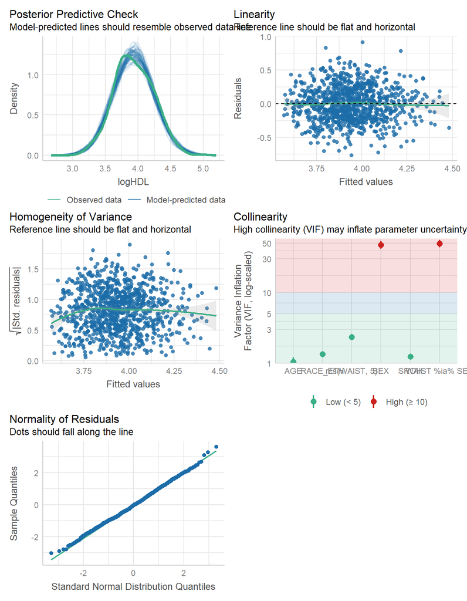

```r
check_model(mod_B, detrend = FALSE)
```

These residual plots also look pretty reasonable, too. Again, I see no clear problems with the assumptions of linearity, normality or constant variance evident in these results. The posterior predictive check is a little better than Model A, but not much. The collinearity we’ve introduced here is due to the interaction terms, so that’s not a concern for us.

## 8.7 Validating Models A and B

We will use the `validate()` function from the **rms** package to validate our `ols` fits.

```r
set.seed(4321); (valA <- validate(mod_A_ols))
```

```
          index.orig training   test optimism index.corrected  n
R-square      0.2729   0.2800 0.2630   0.0170          0.2558 40
MSE           0.0660   0.0656 0.0669  -0.0014          0.0674 40
g             0.1787   0.1811 0.1759   0.0052          0.1736 40
Intercept     0.0000   0.0000 0.1209  -0.1209          0.1209 40
Slope         1.0000   1.0000 0.9689   0.0311          0.9689 40
```

```r
set.seed(4322); (valB <- validate(mod_B_ols))
```

```
          index.orig training   test optimism index.corrected  n
R-square      0.2898   0.3056 0.2790   0.0267          0.2631 40
MSE           0.0645   0.0626 0.0655  -0.0029          0.0674 40
g             0.1827   0.1867 0.1796   0.0072          0.1755 40
Intercept     0.0000   0.0000 0.1501  -0.1501          0.1501 40
Slope         1.0000   1.0000 0.9620   0.0380          0.9620 40
```

### 8.7.1 Validated $R^2$, and MSE as well as IC statistics

**Note**

If you inspect the Quarto code for the table below, you’ll see that I have used in-line coding to specify the values of each element. That’s definitely worth considering in building your work, although it takes some care.

| Model | Validated $R^2$ | Validated MSE | AIC | BIC | df |
| --- | --- | --- | --- | --- | --- |
| A | 0.256 | 0.0674 | 146.4 | 210.1 | 11 |
| B | 0.263 | 0.0674 | 130.8 | 214.2 | 15 |

## 8.8 Final Linear Regression Model

We’ll choose Model B here.

We see a small improvement for Model B in terms of validated $R^2$ and AIC. We also note that BIC is a little lower (thus better) for Model A, and there’s no material difference in validated mean squared error. Each of the models matches the assumptions of linear regression well, so there’s not much to choose from in that regard. Really, we could pick either model here, but I wanted to pick a model with non-linear terms so that I could display and discuss them in what follows.

### 8.8.1 Winning Model’s OLS summary

```r
mod_B_ols
```

```
Linear Regression Model

ols(formula = logHDL ~ AGE + rcs(WAIST, 5) + SEX + WAIST %ia%
    SEX + RACE_ETH + SROH, data = nh_demo_i, x = TRUE, y = TRUE)

                Model Likelihood    Discrimination
                      Ratio Test           Indexes
Obs     999    LR chi2    341.85    R2       0.290
sigma0.2560    d.f.           15    R2 adj   0.279
d.f.    983    Pr(> chi2) 0.0000    g        0.183

Residuals

      Min        1Q    Median        3Q       Max
-0.763472 -0.183023 -0.002842  0.171374  0.916543

                  Coef    S.E.   t     Pr(>|t|)
Intercept          5.4362 0.2523 21.55 <0.0001
AGE                0.0032 0.0008  4.10 <0.0001
WAIST             -0.0170 0.0030 -5.62 <0.0001
WAIST'             0.0387 0.0180  2.15 0.0317
WAIST''           -0.1579 0.0951 -1.66 0.0971
WAIST'''           0.1881 0.1323  1.42 0.1552
SEX=M             -0.1071 0.1115 -0.96 0.3370
WAIST * SEX=M     -0.0005 0.0011 -0.47 0.6367
RACE_ETH=Hispanic -0.0341 0.0220 -1.55 0.1219
RACE_ETH=NH_Black  0.0877 0.0224  3.91 <0.0001
RACE_ETH=NH_Asian -0.0754 0.0276 -2.73 0.0064
RACE_ETH=Other     0.0100 0.0449  0.22 0.8234
SROH=Very_Good    -0.0014 0.0323 -0.04 0.9645
SROH=Good         -0.0635 0.0307 -2.07 0.0389
SROH=Fair         -0.0873 0.0331 -2.64 0.0085
SROH=Poor         -0.0312 0.0498 -0.63 0.5310
```

As a reminder, we displayed the validated $R^2$ value ( = 0.263) for our Model B back in Section 8.7.1.

### 8.8.2 Effects Plot for Winning Model

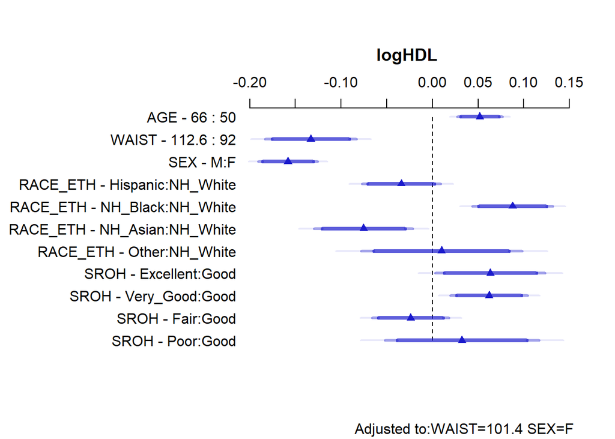

```r
plot(summary(mod_B_ols, conf.int = 0.90))
```

### 8.8.3 Numerical Description of Effect Sizes

```r
summary(mod_B_ols, conf.int = 0.90) |> kable(digits = 3)
```

|  | Low | High | Diff. | Effect | S.E. | Lower 0.9 | Upper 0.9 | Type |
| --- | --- | --- | --- | --- | --- | --- | --- | --- |
| AGE | 50 | 66.0 | 16.0 | 0.052 | 0.013 | 0.031 | 0.073 | 1 |
| WAIST | 92 | 112.6 | 20.6 | -0.133 | 0.026 | -0.175 | -0.091 | 1 |
| SEX - M:F | 1 | 2.0 | NA | -0.158 | 0.017 | -0.186 | -0.131 | 1 |
| RACE_ETH - Hispanic:NH_White | 1 | 2.0 | NA | -0.034 | 0.022 | -0.070 | 0.002 | 1 |
| RACE_ETH - NH_Black:NH_White | 1 | 3.0 | NA | 0.088 | 0.022 | 0.051 | 0.125 | 1 |
| RACE_ETH - NH_Asian:NH_White | 1 | 4.0 | NA | -0.075 | 0.028 | -0.121 | -0.030 | 1 |
| RACE_ETH - Other:NH_White | 1 | 5.0 | NA | 0.010 | 0.045 | -0.064 | 0.084 | 1 |
| SROH - Excellent:Good | 3 | 1.0 | NA | 0.063 | 0.031 | 0.013 | 0.114 | 1 |
| SROH - Very_Good:Good | 3 | 2.0 | NA | 0.062 | 0.022 | 0.027 | 0.097 | 1 |
| SROH - Fair:Good | 3 | 4.0 | NA | -0.024 | 0.022 | -0.059 | 0.012 | 1 |
| SROH - Poor:Good | 3 | 5.0 | NA | 0.032 | 0.043 | -0.039 | 0.103 | 1 |

### 8.8.4 Effect Size Description(s)

In your work, we would only need to see one of the following effect size descriptions.

**WAIST** description: If we have two female subjects of the same age, race/ethnicity and self-reported overall health, then if subject 1 has a waist circumference of 92 cm and subject 2 has a waist circumference of 112.6 cm, then our model estimates that subject 1 will have a log(`HDL`) that is 0.133 higher than subject 2. The 90% confidence interval around that estimated effect on log(HDL) ranges from (0.091, 0.175).

**SROH** description: If we have two subjects of the same age, sex, waist circumference and race/ethnicity. then if subject 1 reports Excellent overall health while subject 2 reports only Good overall health, our model predicts that subject 1’s log(HDL) will be 0.063 higher than subject 2’s log(HDL), with 90% CI (0.013, 0.114).

### 8.8.5 Prediction Plot for Winning Model

Here’s the set of prediction plots to describe the impact of the coefficients on `log(HDL)`.

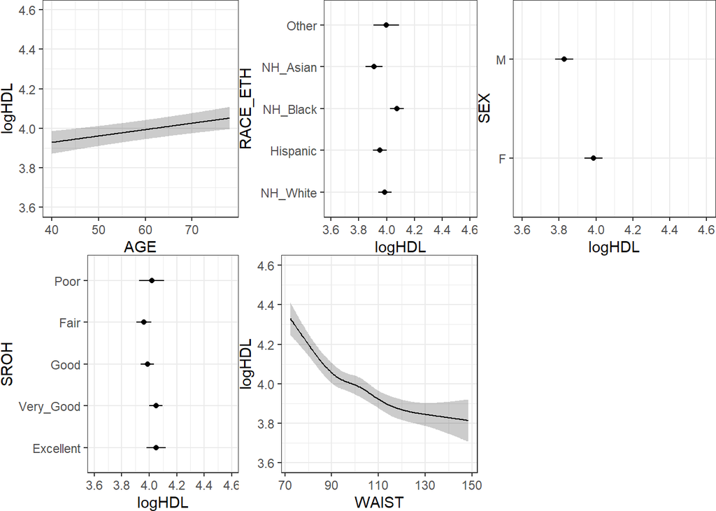

```r
ggplot(Predict(mod_B_ols))
```

### 8.8.6 Nomogram of Winning Model

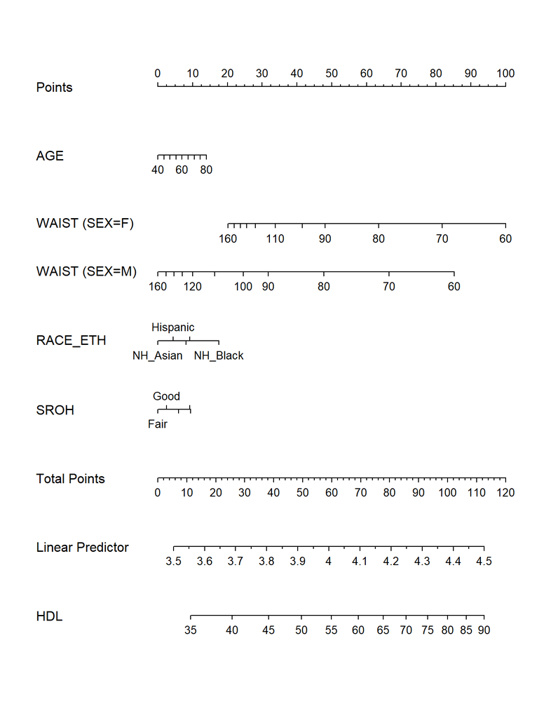

```r
plot(nomogram(mod_B_ols, fun = exp, funlabel = "HDL"))
```

### 8.8.7 Prediction for a New Subject

I will create a predicted HDL for a new female Non-Hispanic White subject who is 60 years old, has an 85 cm waist circumference, and rates their overall health as Fair.

**Note**

I can do this using either the `ols()` or the `lm()` fit to our model. Either is sufficient for Project A, and there’s no need to show both approaches.

**Using the lm() fit**

Here, I’ll actually run two predictions, one for a Male and one for a Female subject with the same values of AGE, WAIST, RACE_ETH and SROH.

```r
new_subjects <-
  data.frame(AGE = c(60,60), WAIST = c(85, 85), SEX = c("M", "F"),
             RACE_ETH = c("NH_White", "NH_White"), SROH = c("Fair", "Fair"))

preds1 <- predict.lm(mod_B, newdata = new_subjects,
                     interval = "prediction", level = 0.90)

exp(preds1)
```

```
       fit      lwr      upr
1 52.08776 34.05169 79.67694
2 60.50899 39.58373 92.49604
```

We then exponentiate these results to obtain the estimate and 90% prediction interval on the original scale of HDL cholesterol, as shown in the table below.

| Predictor Values | Predicted HDL | 90% Prediction Interval |
| --- | --- | --- |
| AGE = 60, WAIST = 85, SEX = M, RACE_ETH = NH_White, SROH = FAIR | 52.09 mg/dl | (34.05, 79.68) mg/dl |
| AGE = 60, WAIST = 85, SEX = F, RACE_ETH = NH_White, SROH = FAIR | 60.51 mg/dl | (39.58, 92.5) mg/dl |

**Using the ols() fit**

Alternatively, I could have used our `ols()` fit. Here, I’ll just fit the results for the female subject.

```r
new_subject <- tibble(  AGE = 60, WAIST = 85, SEX = "F",
                       RACE_ETH = "NH_White", SROH = "Fair" )

preds2 <- predict(mod_B_ols, newdata = new_subject,
                 conf.int = 0.90, conf.type = "individual")

preds2
```

```
$linear.predictors
       1
4.102792

$lower
       1
3.678418

$upper
       1
4.527166
```

We then exponentiate these results to obtain the estimate and 90% prediction interval on the original scale of HDL cholesterol, as shown in the table below.

| Predictor Values | Predicted HDL | 90% Prediction Interval |
| --- | --- | --- |
| AGE = 60, WAIST = 85, SEX = F, RACE_ETH = NH_White, SROH = FAIR | 60.51 mg/dl | (39.58, 92.5) mg/dl |

Naturally, the two fitting approaches (`lm()` and `ols()`) produce the same model, so they produce the same predictions.

# 9 Logistic Regression Analyses

## 9.1 Missingness

Again, we’ll assume missing values are MAR, and use the single imputation approach developed previously in Section 8.1.1.

## 9.2 Model Y

We’ll predict Pr(`HDL_RISK` = 1), the probably of having a low enough `HDL` to put the subject at risk, as a function of `AGE`, `WAIST`, `RACE_ETH` and `SROH`.

### 9.2.1 Fitting Model Y

We’ll fit our logistic regression model using both `glm()` and `lrm()`.

```r
mod_Y <- glm(HDL_RISK ~ AGE + WAIST + RACE_ETH + SROH,
            data = nh_demo_i, family = binomial())

ddd <- datadist(nh_demo_i)
options(datadist = "ddd")

mod_Y_lrm <- lrm(HDL_RISK ~ AGE + WAIST + RACE_ETH + SROH,
                data = nh_demo_i, x = TRUE, y = TRUE)
```

### 9.2.2 Coefficient Estimates

**Note**

I’ll show two different approaches (`model_parameters()` from the `easystats` ecosystem, and `tidy()` from the `broom` package) to summarize the coefficient estimates from `mod_Y`. Either is sufficient for Project A, and there’s no need to show both approaches.

**Tidied Odds Ratio Estimates (Model Y)**

```r
tidy(mod_Y, exponentiate = TRUE, conf.int = TRUE, conf.level = 0.90) |>
  select(term, estimate, se = std.error,
         low90 = conf.low, high90 = conf.high, p = p.value) |>
  kable(digits = 3)
```

| term | estimate | se | low90 | high90 | p |
| --- | --- | --- | --- | --- | --- |
| (Intercept) | 0.011 | 0.722 | 0.003 | 0.036 | 0.000 |
| AGE | 0.986 | 0.007 | 0.975 | 0.998 | 0.048 |
| WAIST | 1.041 | 0.005 | 1.032 | 1.050 | 0.000 |
| RACE_ETHHispanic | 1.004 | 0.189 | 0.736 | 1.369 | 0.983 |
| RACE_ETHNH_Black | 0.531 | 0.203 | 0.379 | 0.740 | 0.002 |
| RACE_ETHNH_Asian | 1.607 | 0.239 | 1.083 | 2.380 | 0.047 |
| RACE_ETHOther | 0.536 | 0.420 | 0.261 | 1.049 | 0.138 |
| SROHVery_Good | 1.196 | 0.318 | 0.717 | 2.044 | 0.574 |
| SROHGood | 1.677 | 0.300 | 1.037 | 2.792 | 0.085 |
| SROHFair | 2.405 | 0.315 | 1.448 | 4.100 | 0.005 |
| SROHPoor | 1.993 | 0.450 | 0.949 | 4.193 | 0.126 |

**Model Y Parameters**

```r
model_parameters(mod_Y, ci = 0.90, exponentiate = TRUE) |>
  print_md(digits = 3)
```

| Parameter | Odds Ratio | SE | 90% CI | z | p |
| --- | --- | --- | --- | --- | --- |
| (Intercept) | 0.011 | 0.008 | (0.003, 0.036) | -6.243 | < .001 |
| AGE | 0.986 | 0.007 | (0.975, 0.998) | -1.979 | 0.048 |
| WAIST | 1.041 | 0.005 | (1.032, 1.050) | 7.779 | < .001 |
| RACE ETH (Hispanic) | 1.004 | 0.189 | (0.736, 1.369) | 0.022 | 0.983 |
| RACE ETH (NH_Black) | 0.531 | 0.108 | (0.379, 0.740) | -3.114 | 0.002 |
| RACE ETH (NH_Asian) | 1.607 | 0.384 | (1.083, 2.380) | 1.985 | 0.047 |
| RACE ETH (Other) | 0.536 | 0.225 | (0.261, 1.049) | -1.483 | 0.138 |
| SROH (Very_Good) | 1.196 | 0.380 | (0.717, 2.044) | 0.562 | 0.574 |
| SROH (Good) | 1.677 | 0.503 | (1.037, 2.792) | 1.722 | 0.085 |
| SROH (Fair) | 2.405 | 0.759 | (1.448, 4.100) | 2.782 | 0.005 |
| SROH (Poor) | 1.993 | 0.897 | (0.949, 4.193) | 1.531 | 0.126 |

### 9.2.3 Model Y Effects

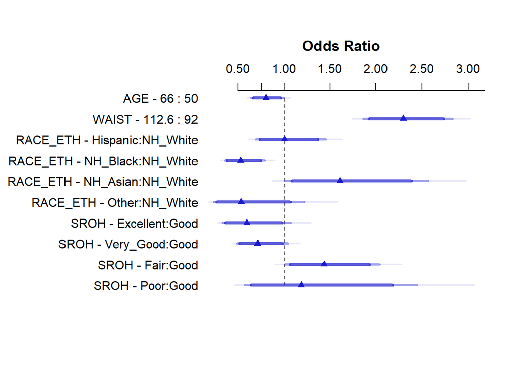

```r
plot(summary(mod_Y_lrm, conf.int = 0.90))
```

```r
summary(mod_Y_lrm, conf.int = 0.90) |> kable(digits = 3)
```

|  | Low | High | Diff. | Effect | S.E. | Lower 0.9 | Upper 0.9 | Type |
| --- | --- | --- | --- | --- | --- | --- | --- | --- |
| AGE | 50 | 66.0 | 16.0 | -0.221 | 0.112 | -0.404 | -0.037 | 1 |
| Odds Ratio | 50 | 66.0 | 16.0 | 0.802 | NA | 0.667 | 0.963 | 2 |
| WAIST | 92 | 112.6 | 20.6 | 0.831 | 0.107 | 0.655 | 1.006 | 1 |
| Odds Ratio | 92 | 112.6 | 20.6 | 2.295 | NA | 1.925 | 2.735 | 2 |
| RACE_ETH - Hispanic:NH_White | 1 | 2.0 | NA | 0.004 | 0.189 | -0.306 | 0.314 | 1 |
| Odds Ratio | 1 | 2.0 | NA | 1.004 | NA | 0.736 | 1.369 | 2 |
| RACE_ETH - NH_Black:NH_White | 1 | 3.0 | NA | -0.633 | 0.203 | -0.967 | -0.299 | 1 |
| Odds Ratio | 1 | 3.0 | NA | 0.531 | NA | 0.380 | 0.742 | 2 |
| RACE_ETH - NH_Asian:NH_White | 1 | 4.0 | NA | 0.474 | 0.239 | 0.081 | 0.867 | 1 |
| Odds Ratio | 1 | 4.0 | NA | 1.607 | NA | 1.085 | 2.381 | 2 |
| RACE_ETH - Other:NH_White | 1 | 5.0 | NA | -0.624 | 0.420 | -1.315 | 0.068 | 1 |
| Odds Ratio | 1 | 5.0 | NA | 0.536 | NA | 0.268 | 1.070 | 2 |
| SROH - Excellent:Good | 3 | 1.0 | NA | -0.517 | 0.300 | -1.010 | -0.023 | 1 |
| Odds Ratio | 3 | 1.0 | NA | 0.596 | NA | 0.364 | 0.977 | 2 |
| SROH - Very_Good:Good | 3 | 2.0 | NA | -0.338 | 0.193 | -0.656 | -0.020 | 1 |
| Odds Ratio | 3 | 2.0 | NA | 0.713 | NA | 0.519 | 0.980 | 2 |
| SROH - Fair:Good | 3 | 4.0 | NA | 0.361 | 0.180 | 0.065 | 0.656 | 1 |
| Odds Ratio | 3 | 4.0 | NA | 1.434 | NA | 1.067 | 1.928 | 2 |
| SROH - Poor:Good | 3 | 5.0 | NA | 0.173 | 0.368 | -0.433 | 0.778 | 1 |
| Odds Ratio | 3 | 5.0 | NA | 1.188 | NA | 0.649 | 2.177 | 2 |

### 9.2.4 Quality of Fit Summaries

**Note**

Here, we have three available approaches to summarize the fit of Model Y, thanks to our `glm()` and `lrm()` fits of the same model. I’ll show all three, but in practice (and in your Project A) I wouldn’t include the `model_performance()` results.

**lrm() for Model Y**

Our Nagelkerke $R^2$ estimate for Model Y is 0.152, and our C statistic is estimated to be 0.701.

```r
mod_Y_lrm
```

```
Logistic Regression Model

lrm(formula = HDL_RISK ~ AGE + WAIST + RACE_ETH + SROH, data = nh_demo_i,
    x = TRUE, y = TRUE)

                       Model Likelihood     Discrimination    Rank Discrim.
                             Ratio Test            Indexes          Indexes
Obs           999    LR chi2     115.50     R2       0.152    C       0.701
 0            666    d.f.            10    R2(10,999)0.100    Dxy     0.402
 1            333    Pr(> chi2) <0.0001    R2(10,666)0.146    gamma   0.402
max |deriv| 1e-06                           Brier    0.198    tau-a   0.179

                  Coef    S.E.   Wald Z Pr(>|Z|)
Intercept         -4.5080 0.7221 -6.24  <0.0001
AGE               -0.0138 0.0070 -1.98  0.0478
WAIST              0.0403 0.0052  7.78  <0.0001
RACE_ETH=Hispanic  0.0041 0.1886  0.02  0.9826
RACE_ETH=NH_Black -0.6327 0.2032 -3.11  0.0018
RACE_ETH=NH_Asian  0.4743 0.2390  1.98  0.0472
RACE_ETH=Other    -0.6235 0.4205 -1.48  0.1381
SROH=Very_Good     0.1786 0.3175  0.56  0.5739
SROH=Good          0.5168 0.3001  1.72  0.0850
SROH=Fair          0.8776 0.3154  2.78  0.0054
SROH=Poor          0.6895 0.4503  1.53  0.1258
```

**glance at Model Y**

The `glance()` results below give us our AIC and BIC values, as well as the degrees of freedom used by Model Y.

```r
glance(mod_Y) |>
  mutate(df = nobs - df.residual - 1) |>
  select(AIC, BIC, df, df.residual, nobs) |>
  kable(digits = 1)
```

| AIC | BIC | df | df.residual | nobs |
| --- | --- | --- | --- | --- |
| 1178.3 | 1232.2 | 10 | 988 | 999 |

**Model Y Performance**

**Note**

These summaries aren’t as appealing to me as those in the other two tabs here.

```r
model_performance(mod_Y) |> print_md(digits = 2)
```

Indices of model performance

| AIC | AICc | BIC | Tjur’s R2 | RMSE | Sigma | Log_loss | Score_log | Score_spherical | PCP |
| --- | --- | --- | --- | --- | --- | --- | --- | --- | --- |
| 1178.26 | 1178.53 | 1232.23 | 0.11 | 0.44 | 1.00 | 0.58 | -145.30 | 1.81e-03 | 0.60 |

### 9.2.5 Confusion Matrix (Model Y)

First, we augment our `nh_demo_i` data to include predicted probabilities of (HDL_RISK = 1) from Model Y.

```r
resY_aug <- augment(mod_Y, type.predict = "response")
```

My prediction rule for this confusion matrix is that the fitted value of Pr(HDL_RISK = 1) needs to be greater than or equal to 0.5 for me to predict HDL_RISK is 1, and otherwise I predict 0.

```r
cm_Y <- caret::confusionMatrix(
  data = factor(resY_aug$.fitted >= 0.5),
  reference = factor(resY_aug$HDL_RISK == 1),
  positive = "TRUE")

cm_Y
```

```
Confusion Matrix and Statistics

          Reference
Prediction FALSE TRUE
     FALSE   603  241
     TRUE     63   92

               Accuracy : 0.6957
                 95% CI : (0.6661, 0.7241)
    No Information Rate : 0.6667
    P-Value [Acc > NIR] : 0.02722

                  Kappa : 0.2097

 Mcnemar's Test P-Value : < 2e-16

            Sensitivity : 0.27628
            Specificity : 0.90541
         Pos Pred Value : 0.59355
         Neg Pred Value : 0.71445
             Prevalence : 0.33333
         Detection Rate : 0.09209
   Detection Prevalence : 0.15516
      Balanced Accuracy : 0.59084

       'Positive' Class : TRUE
```

Here are our results, tabulated nicely.

| Model | Classification Rule | Sensitivity | Specificity | Pos. Pred. Value |
| --- | --- | --- | --- | --- |
| Y | Predicted Pr(HDL_RISK = 1) >= 0.5 | 0.276 | 0.905 | 0.594 |

## 9.3 Non-Linearity and Spearman $\rho^2$ plot

Here’s the relevant Spearman $\rho^2$ plot.

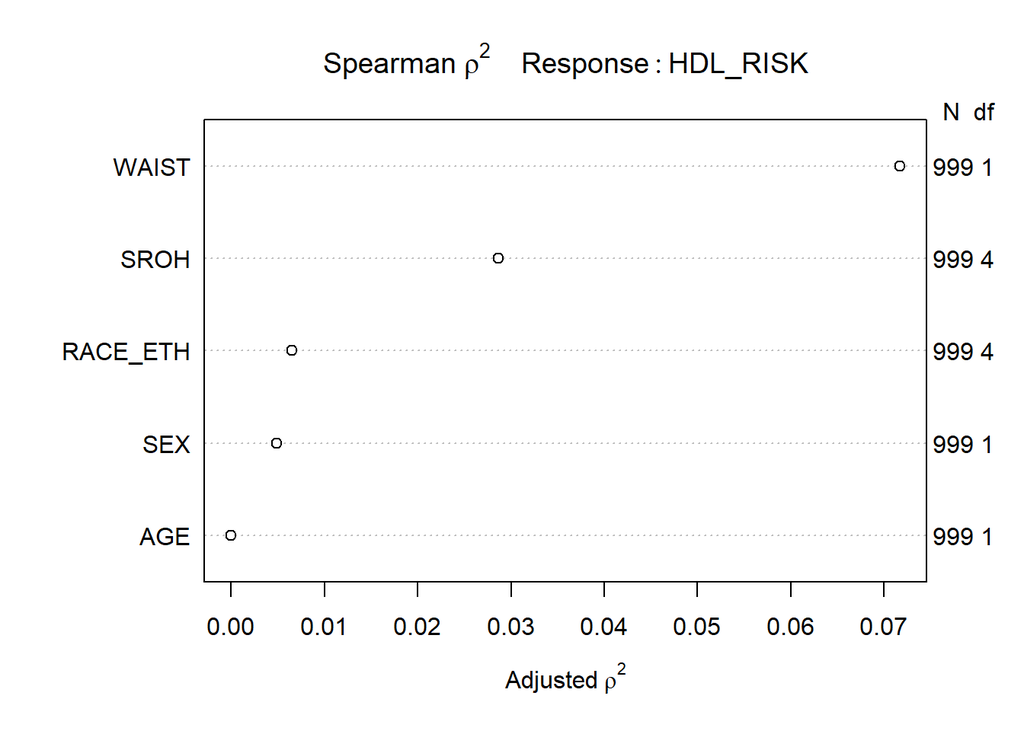

```r
plot(spearman2(HDL_RISK ~ AGE + WAIST + SEX + RACE_ETH + SROH,
               data = nh_demo_i))
```

Our Spearman $\rho^2$ plot first suggests the use of a non-linear term in `WAIST`, so we’ll add a restricted cubic spline in `WAIST` using 4 knots, which should add 2 degrees of freedom to our initial model.

Next, the `SROH` variable seems to be a good choice, so we’ll add an interaction between `SROH` and the main effect of `WAIST`, which will add four more degrees of freedom to our model Y.

## 9.4 Model Z

As mentioned, our model Z will add 6 degrees of freedom through two non-linear terms, to model Y.

### 9.4.1 Fitting Model Z

We’ll fit Model Z with both `glm()` and `lrm()`.

```r
mod_Z <- glm(HDL_RISK ~ AGE + rcs(WAIST, 4) + RACE_ETH +
               SROH + WAIST %ia% SROH,
            data = nh_demo_i, family = binomial())

ddd <- datadist(nh_demo_i)
options(datadist = "ddd")

mod_Z_lrm <- lrm(HDL_RISK ~ AGE + rcs(WAIST, 4) + RACE_ETH +
                   SROH + WAIST %ia% SROH,
                 data = nh_demo_i, x = TRUE, y = TRUE)
```

### 9.4.2 Coefficient Estimates

**Note**

I’ll show two different approaches (`model_parameters()` from the `easystats` ecosystem, and `tidy()` from the `broom` package) to summarize the coefficient estimates from `mod_Y`. Either is sufficient for Project A, and there’s no need to show both approaches. The `tidy()` approach handles the non-linear terms a bit better in my view, so I’d probably go with that.

**Tidied Odds Ratio Estimates (Model Z)**

```r
tidy(mod_Z, exponentiate = TRUE, conf.int = TRUE, conf.level = 0.90) |>
  select(term, estimate, se = std.error,
         low90 = conf.low, high90 = conf.high, p = p.value) |>
  kable(digits = 3)
```

| term | estimate | se | low90 | high90 | p |
| --- | --- | --- | --- | --- | --- |
| (Intercept) | 0.000 | 2.905 | 0.000 | 0.018 | 0.003 |
| AGE | 0.985 | 0.007 | 0.973 | 0.996 | 0.032 |
| rcs(WAIST, 4)WAIST | 1.093 | 0.032 | 1.039 | 1.154 | 0.005 |
| rcs(WAIST, 4)WAIST’ | 0.893 | 0.074 | 0.787 | 1.006 | 0.128 |
| rcs(WAIST, 4)WAIST’’ | 1.295 | 0.231 | 0.890 | 1.909 | 0.263 |
| RACE_ETHHispanic | 0.971 | 0.190 | 0.710 | 1.326 | 0.875 |
| RACE_ETHNH_Black | 0.525 | 0.203 | 0.375 | 0.732 | 0.002 |
| RACE_ETHNH_Asian | 1.739 | 0.248 | 1.157 | 2.615 | 0.025 |
| RACE_ETHOther | 0.541 | 0.419 | 0.264 | 1.056 | 0.142 |
| SROHVery_Good | 0.630 | 2.352 | 0.013 | 31.942 | 0.845 |
| SROHGood | 1.151 | 2.158 | 0.032 | 43.328 | 0.948 |
| SROHFair | 0.437 | 2.246 | 0.010 | 18.809 | 0.713 |
| SROHPoor | 1.828 | 2.837 | 0.015 | 187.479 | 0.832 |
| WAIST %ia% SROHWAIST * SROH=Very_Good | 1.006 | 0.024 | 0.968 | 1.047 | 0.791 |
| WAIST %ia% SROHWAIST * SROH=Good | 1.004 | 0.022 | 0.968 | 1.041 | 0.860 |
| WAIST %ia% SROHWAIST * SROH=Fair | 1.017 | 0.022 | 0.979 | 1.056 | 0.462 |
| WAIST %ia% SROHWAIST * SROH=Poor | 1.002 | 0.027 | 0.959 | 1.049 | 0.936 |

**Model Z Parameters**

```r
model_parameters(mod_Z, ci = 0.90, exponentiate = TRUE) |>
  print_md(digits = 3)
```

| Parameter | Odds Ratio | SE | 90% CI | z | p |
| --- | --- | --- | --- | --- | --- |
| (Intercept) | 1.765e-04 | 5.127e-04 | (1.213e-06, 0.018) | -2.975 | 0.003 |
| AGE | 0.985 | 0.007 | (0.973, 0.996) | -2.150 | 0.032 |
| rcs(WAIST ( degree) | 1.093 | 0.035 | (1.039, 1.154) | 2.791 | 0.005 |
| rcs(WAIST ( degree) | 0.893 | 0.066 | (0.787, 1.006) | -1.523 | 0.128 |
| rcs(WAIST ( degree) | 1.295 | 0.300 | (0.890, 1.909) | 1.118 | 0.263 |
| RACE ETH (Hispanic) | 0.971 | 0.184 | (0.710, 1.326) | -0.157 | 0.875 |
| RACE ETH (NH_Black) | 0.525 | 0.107 | (0.375, 0.732) | -3.164 | 0.002 |
| RACE ETH (NH_Asian) | 1.739 | 0.431 | (1.157, 2.615) | 2.236 | 0.025 |
| RACE ETH (Other) | 0.541 | 0.227 | (0.264, 1.056) | -1.467 | 0.142 |
| SROH (Very_Good) | 0.630 | 1.483 | (0.013, 31.942) | -0.196 | 0.845 |
| SROH (Good) | 1.151 | 2.485 | (0.032, 43.328) | 0.065 | 0.948 |
| SROH (Fair) | 0.437 | 0.982 | (0.010, 18.809) | -0.368 | 0.713 |
| SROH (Poor) | 1.828 | 5.185 | (0.015, 187.479) | 0.213 | 0.832 |
| WAIST %ia% SROHWAIST * SROH=Very Good | 1.006 | 0.024 | (0.968, 1.047) | 0.265 | 0.791 |
| WAIST %ia% SROHWAIST * SROH=Good | 1.004 | 0.022 | (0.968, 1.041) | 0.176 | 0.860 |
| WAIST %ia% SROHWAIST * SROH=Fair | 1.017 | 0.023 | (0.979, 1.056) | 0.735 | 0.462 |
| WAIST %ia% SROHWAIST * SROH=Poor | 1.002 | 0.027 | (0.959, 1.049) | 0.081 | 0.936 |

### 9.4.3 Model Z Effects

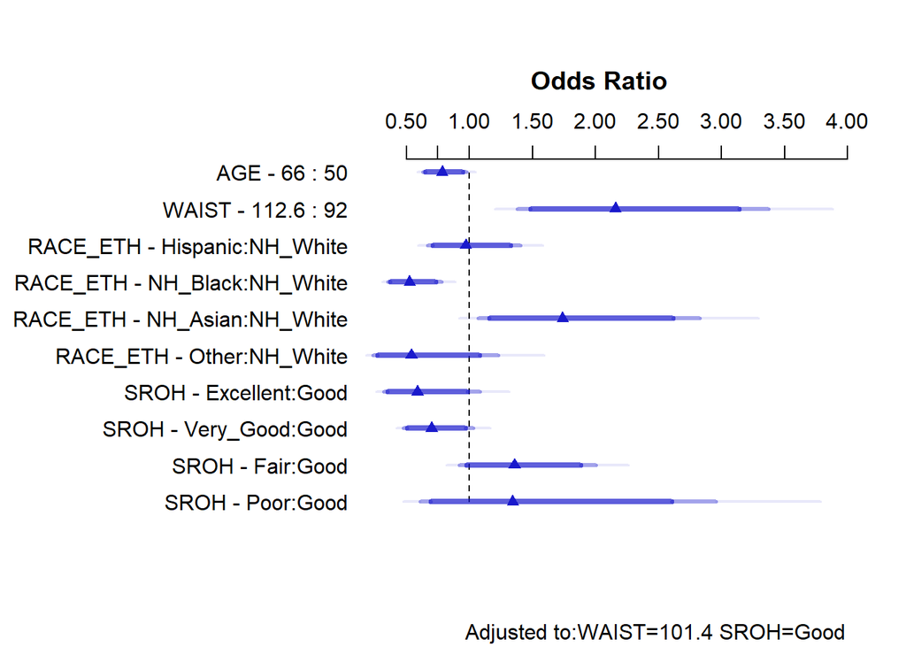

```r
plot(summary(mod_Z_lrm, conf.int = 0.90))
```

```r
summary(mod_Z_lrm, conf.int = 0.90) |> kable(digits = 3)
```

|  | Low | High | Diff. | Effect | S.E. | Lower 0.9 | Upper 0.9 | Type |
| --- | --- | --- | --- | --- | --- | --- | --- | --- |
| AGE | 50 | 66.0 | 16.0 | -0.243 | 0.113 | -0.429 | -0.057 | 1 |
| Odds Ratio | 50 | 66.0 | 16.0 | 0.784 | NA | 0.651 | 0.944 | 2 |
| WAIST | 92 | 112.6 | 20.6 | 0.769 | 0.228 | 0.395 | 1.144 | 1 |
| Odds Ratio | 92 | 112.6 | 20.6 | 2.158 | NA | 1.484 | 3.140 | 2 |
| RACE_ETH - Hispanic:NH_White | 1 | 2.0 | NA | -0.030 | 0.190 | -0.342 | 0.283 | 1 |
| Odds Ratio | 1 | 2.0 | NA | 0.971 | NA | 0.710 | 1.327 | 2 |
| RACE_ETH - NH_Black:NH_White | 1 | 3.0 | NA | -0.644 | 0.203 | -0.979 | -0.309 | 1 |
| Odds Ratio | 1 | 3.0 | NA | 0.525 | NA | 0.376 | 0.734 | 2 |
| RACE_ETH - NH_Asian:NH_White | 1 | 4.0 | NA | 0.553 | 0.248 | 0.146 | 0.961 | 1 |
| Odds Ratio | 1 | 4.0 | NA | 1.739 | NA | 1.157 | 2.613 | 2 |
| RACE_ETH - Other:NH_White | 1 | 5.0 | NA | -0.615 | 0.419 | -1.304 | 0.074 | 1 |
| Odds Ratio | 1 | 5.0 | NA | 0.541 | NA | 0.271 | 1.077 | 2 |
| SROH - Excellent:Good | 3 | 1.0 | NA | -0.529 | 0.311 | -1.041 | -0.017 | 1 |
| Odds Ratio | 3 | 1.0 | NA | 0.589 | NA | 0.353 | 0.983 | 2 |
| SROH - Very_Good:Good | 3 | 2.0 | NA | -0.355 | 0.197 | -0.680 | -0.031 | 1 |
| Odds Ratio | 3 | 2.0 | NA | 0.701 | NA | 0.507 | 0.969 | 2 |
| SROH - Fair:Good | 3 | 4.0 | NA | 0.306 | 0.198 | -0.019 | 0.632 | 1 |
| Odds Ratio | 3 | 4.0 | NA | 1.359 | NA | 0.981 | 1.882 | 2 |
| SROH - Poor:Good | 3 | 5.0 | NA | 0.295 | 0.402 | -0.366 | 0.956 | 1 |
| Odds Ratio | 3 | 5.0 | NA | 1.344 | NA | 0.694 | 2.602 | 2 |

### 9.4.4 Quality of Fit Summaries

**Note**

Again, we have three available approaches to summarize the fit of Model Z, thanks to our `glm()` and `lrm()` fits of the same model. I’ll show all three, but in practice (and in your Project A) I wouldn’t include the `model_performance()` results.

**lrm() for Model Z**

Our Nagelkerke $R^2$ estimate for Model Z is 0.162, and our C statistic is estimated to be 0.702.

```r
mod_Z_lrm
```

```
Logistic Regression Model

lrm(formula = HDL_RISK ~ AGE + rcs(WAIST, 4) + RACE_ETH + SROH +
    WAIST %ia% SROH, data = nh_demo_i, x = TRUE, y = TRUE)

                       Model Likelihood     Discrimination    Rank Discrim.
                             Ratio Test            Indexes          Indexes
Obs           999    LR chi2     123.92     R2       0.162    C       0.702
 0            666    d.f.            16    R2(16,999)0.102    Dxy     0.404
 1            333    Pr(> chi2) <0.0001    R2(16,666)0.150    gamma   0.404
max |deriv| 3e-08                           Brier    0.197    tau-a   0.180

                       Coef    S.E.   Wald Z Pr(>|Z|)
Intercept              -8.6421 2.9045 -2.98  0.0029
AGE                    -0.0152 0.0071 -2.15  0.0315
WAIST                   0.0887 0.0318  2.79  0.0053
WAIST'                 -0.1134 0.0745 -1.52  0.1277
WAIST''                 0.2588 0.2314  1.12  0.2634
RACE_ETH=Hispanic      -0.0299 0.1900 -0.16  0.8751
RACE_ETH=NH_Black      -0.6438 0.2035 -3.16  0.0016
RACE_ETH=NH_Asian       0.5535 0.2476  2.24  0.0254
RACE_ETH=Other         -0.6148 0.4189 -1.47  0.1422
SROH=Very_Good         -0.4613 2.3523 -0.20  0.8445
SROH=Good               0.1409 2.1582  0.07  0.9480
SROH=Fair              -0.8270 2.2460 -0.37  0.7127
SROH=Poor               0.6031 2.8370  0.21  0.8317
WAIST * SROH=Very_Good  0.0063 0.0236  0.27  0.7908
WAIST * SROH=Good       0.0038 0.0217  0.18  0.8602
WAIST * SROH=Fair       0.0164 0.0223  0.73  0.4625
WAIST * SROH=Poor       0.0022 0.0271  0.08  0.9356
```

**glance at Model Z**

The `glance()` results below give us our AIC and BIC values, as well as the degrees of freedom used by Model Z.

```r
glance(mod_Z) |>
  mutate(df = nobs - df.residual - 1) |>
  select(AIC, BIC, df, df.residual, nobs) |>
  kable(digits = 1)
```

| AIC | BIC | df | df.residual | nobs |
| --- | --- | --- | --- | --- |
| 1181.8 | 1265.3 | 16 | 982 | 999 |

**Model Z Performance**

**Note**

As mentioned previously, these summaries aren’t as appealing to me as those in the other two tabs here.

```r
model_performance(mod_Z) |> print_md(digits = 2)
```

Indices of model performance

| AIC | AICc | BIC | Tjur’s R2 | RMSE | Sigma | Log_loss | Score_log | Score_spherical | PCP |
| --- | --- | --- | --- | --- | --- | --- | --- | --- | --- |
| 1181.84 | 1182.46 | 1265.25 | 0.12 | 0.44 | 1.00 | 0.57 | -144.81 | 1.60e-03 | 0.61 |

### 9.4.5 Confusion Matrix (Model Z)

As in Model Y, my prediction rule for my Model Z confusion matrix is that the fitted value of Pr(HDL_RISK = 1) needs to be greater than or equal to 0.5 for me to predict HDL_RISK is 1, and otherwise I predict 0.

Again, we augment our `nh_demo_i` data to include predicted probabilities of (HDL_RISK = 1) from Model Z.

```r
resZ_aug <- augment(mod_Z, type.predict = "response")
```

Applying my prediction rule, we obtain:

```r
cm_Z <- caret::confusionMatrix(
  data = factor(resZ_aug$.fitted >= 0.5),
  reference = factor(resZ_aug$HDL_RISK == 1),
  positive = "TRUE")

cm_Z
```

```
Confusion Matrix and Statistics

          Reference
Prediction FALSE TRUE
     FALSE   608  241
     TRUE     58   92

               Accuracy : 0.7007
                 95% CI : (0.6712, 0.729)
    No Information Rate : 0.6667
    P-Value [Acc > NIR] : 0.01177

                  Kappa : 0.2193

 Mcnemar's Test P-Value : < 2e-16

            Sensitivity : 0.27628
            Specificity : 0.91291
         Pos Pred Value : 0.61333
         Neg Pred Value : 0.71614
             Prevalence : 0.33333
         Detection Rate : 0.09209
   Detection Prevalence : 0.15015
      Balanced Accuracy : 0.59459

       'Positive' Class : TRUE
```

Here are our results comparing classification performance by models Y and Z.

| Model | Classification Rule | Sensitivity | Specificity | Pos. Pred. Value |
| --- | --- | --- | --- | --- |
| Y | Predicted Pr(HDL_RISK = 1) >= 0.5 | 0.276 | 0.905 | 0.594 |
| Z | Predicted Pr(HDL_RISK = 1) >= 0.5 | 0.276 | 0.913 | 0.613 |

## 9.5 Validating Models Y and Z

We will use the `validate()` function from the **rms** package to validate our `lrm` fits.

```r
set.seed(4323); (valY <- validate(mod_Y_lrm))
```

```
          index.orig training    test optimism index.corrected  n
Dxy           0.4017   0.4207  0.3843   0.0364          0.3652 40
R2            0.1516   0.1668  0.1406   0.0262          0.1254 40
Intercept     0.0000   0.0000 -0.0602   0.0602         -0.0602 40
Slope         1.0000   1.0000  0.9034   0.0966          0.9034 40
Emax          0.0000   0.0000  0.0329   0.0329          0.0329 40
D             0.1146   0.1272  0.1057   0.0215          0.0932 40
U            -0.0020  -0.0020  0.0010  -0.0030          0.0010 40
Q             0.1166   0.1292  0.1047   0.0245          0.0921 40
B             0.1979   0.1956  0.2003  -0.0047          0.2026 40
g             0.8757   0.9354  0.8396   0.0959          0.7798 40
gp            0.1767   0.1855  0.1701   0.0154          0.1612 40
```

```r
set.seed(4324); (valZ <- validate(mod_Z_lrm))
```

```
          index.orig training    test optimism index.corrected  n
Dxy           0.4036   0.4267  0.3867   0.0400          0.3636 40
R2            0.1620   0.1806  0.1461   0.0345          0.1275 40
Intercept     0.0000   0.0000 -0.0896   0.0896         -0.0896 40
Slope         1.0000   1.0000  0.8674   0.1326          0.8674 40
Emax          0.0000   0.0000  0.0474   0.0474          0.0474 40
D             0.1230   0.1386  0.1102   0.0284          0.0946 40
U            -0.0020  -0.0020  0.0021  -0.0041          0.0021 40
Q             0.1250   0.1406  0.1081   0.0325          0.0925 40
B             0.1968   0.1938  0.2000  -0.0062          0.2030 40
g             0.9605   1.0350  0.8957   0.1393          0.8212 40
gp            0.1825   0.1924  0.1724   0.0200          0.1626 40
```

### 9.5.1 Validated Nagelkerke $R^2$, and C, as well as IC statistics

| Model | Validated $R^2$ | Validated C | AIC | BIC | df |
| --- | --- | --- | --- | --- | --- |
| Y | 0.1254 | 0.6826 | 1178.3 | 1232.2 | 10 |
| Z | 0.1275 | 0.6818 | 1181.8 | 1265.3 | 16 |

## 9.6 Final Logistic Regression Model

I prefer Model Y, because of its slightly better AIC, BIC and validated C statistic, despite the fact that Model Z has a slightly higher validated $R^2$ and that Model Z also has a slightly higher positive predictive value. It’s pretty close, though.

### 9.6.1 Winning Model’s Parameter Estimates

```r
mod_Y_lrm
```

```
Logistic Regression Model

lrm(formula = HDL_RISK ~ AGE + WAIST + RACE_ETH + SROH, data = nh_demo_i,
    x = TRUE, y = TRUE)

                       Model Likelihood     Discrimination    Rank Discrim.
                             Ratio Test            Indexes          Indexes
Obs           999    LR chi2     115.50     R2       0.152    C       0.701
 0            666    d.f.            10    R2(10,999)0.100    Dxy     0.402
 1            333    Pr(> chi2) <0.0001    R2(10,666)0.146    gamma   0.402
max |deriv| 1e-06                           Brier    0.198    tau-a   0.179

                  Coef    S.E.   Wald Z Pr(>|Z|)
Intercept         -4.5080 0.7221 -6.24  <0.0001
AGE               -0.0138 0.0070 -1.98  0.0478
WAIST              0.0403 0.0052  7.78  <0.0001
RACE_ETH=Hispanic  0.0041 0.1886  0.02  0.9826
RACE_ETH=NH_Black -0.6327 0.2032 -3.11  0.0018
RACE_ETH=NH_Asian  0.4743 0.2390  1.98  0.0472
RACE_ETH=Other    -0.6235 0.4205 -1.48  0.1381
SROH=Very_Good     0.1786 0.3175  0.56  0.5739
SROH=Good          0.5168 0.3001  1.72  0.0850
SROH=Fair          0.8776 0.3154  2.78  0.0054
SROH=Poor          0.6895 0.4503  1.53  0.1258
```

### 9.6.2 Winning Model Effect Sizes

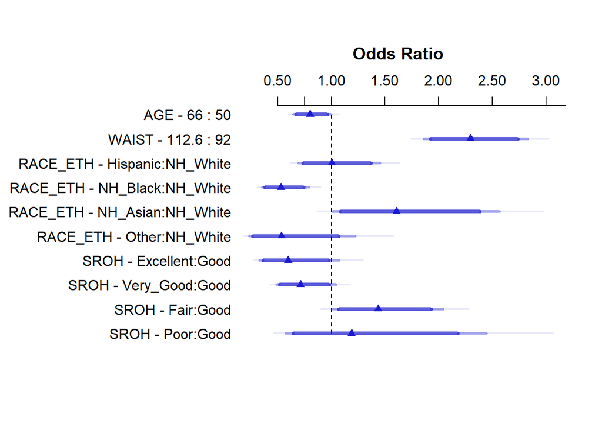

```r
plot(summary(mod_Y_lrm, conf.int = 0.90))
```

### 9.6.3 Numerical Description of Effect Sizes

```r
summary(mod_Y_lrm, conf.int = 0.90) |> kable(digits = 3)
```

|  | Low | High | Diff. | Effect | S.E. | Lower 0.9 | Upper 0.9 | Type |
| --- | --- | --- | --- | --- | --- | --- | --- | --- |
| AGE | 50 | 66.0 | 16.0 | -0.221 | 0.112 | -0.404 | -0.037 | 1 |
| Odds Ratio | 50 | 66.0 | 16.0 | 0.802 | NA | 0.667 | 0.963 | 2 |
| WAIST | 92 | 112.6 | 20.6 | 0.831 | 0.107 | 0.655 | 1.006 | 1 |
| Odds Ratio | 92 | 112.6 | 20.6 | 2.295 | NA | 1.925 | 2.735 | 2 |
| RACE_ETH - Hispanic:NH_White | 1 | 2.0 | NA | 0.004 | 0.189 | -0.306 | 0.314 | 1 |
| Odds Ratio | 1 | 2.0 | NA | 1.004 | NA | 0.736 | 1.369 | 2 |
| RACE_ETH - NH_Black:NH_White | 1 | 3.0 | NA | -0.633 | 0.203 | -0.967 | -0.299 | 1 |
| Odds Ratio | 1 | 3.0 | NA | 0.531 | NA | 0.380 | 0.742 | 2 |
| RACE_ETH - NH_Asian:NH_White | 1 | 4.0 | NA | 0.474 | 0.239 | 0.081 | 0.867 | 1 |
| Odds Ratio | 1 | 4.0 | NA | 1.607 | NA | 1.085 | 2.381 | 2 |
| RACE_ETH - Other:NH_White | 1 | 5.0 | NA | -0.624 | 0.420 | -1.315 | 0.068 | 1 |
| Odds Ratio | 1 | 5.0 | NA | 0.536 | NA | 0.268 | 1.070 | 2 |
| SROH - Excellent:Good | 3 | 1.0 | NA | -0.517 | 0.300 | -1.010 | -0.023 | 1 |
| Odds Ratio | 3 | 1.0 | NA | 0.596 | NA | 0.364 | 0.977 | 2 |
| SROH - Very_Good:Good | 3 | 2.0 | NA | -0.338 | 0.193 | -0.656 | -0.020 | 1 |
| Odds Ratio | 3 | 2.0 | NA | 0.713 | NA | 0.519 | 0.980 | 2 |
| SROH - Fair:Good | 3 | 4.0 | NA | 0.361 | 0.180 | 0.065 | 0.656 | 1 |
| Odds Ratio | 3 | 4.0 | NA | 1.434 | NA | 1.067 | 1.928 | 2 |
| SROH - Poor:Good | 3 | 5.0 | NA | 0.173 | 0.368 | -0.433 | 0.778 | 1 |
| Odds Ratio | 3 | 5.0 | NA | 1.188 | NA | 0.649 | 2.177 | 2 |

### 9.6.4 Effect Size Description(s)

In your work, we would only need to see one of the following effect size descriptions.

**WAIST** description: If we have two subjects of the same age, race/ethnicity and self-reported overall health, then if subject 1 has a waist circumference of 92 cm and subject 2 has a waist circumference of 112.6 cm, then our model estimates that subject 2 will have 2.295 times the odds (90% CI: 1.93, 2.74) that subject 1 has of having a HDL that is at risk.

**AGE** description: If we have two subjects of the same waist circumference, race/ethnicity and self-reported overall health, then if subject 1 is age 50 and subject 2 is age 66, our model predicts that subject 2 has 80.2% of the odds of an at-risk HDL that subject 1 has. The 90% CI for the odds ratio comparing subject 1 to subject 2 is (0.667, 0.963).

**SROH** description: If we have two subjects of the same age, waist circumference and race/ethnicity. then if subject 1 reports Excellent overall health while subject 2 reports only Good overall health, our model predicts that the odds ratio comparing subject 1’s odds of an at-risk HDL to those of subject 2 will be 0.596, with a 90% CI of (0.364, 0.977).

### 9.6.5 Validated $R^2$ and $C$ statistic for Winning Model

As we saw in Section 9.5.1,

- the validated $R^2$ statistic for Model Y is 0.1254, and
- the validated $C$ statistic for Model Y is 0.6826.

### 9.6.6 Nomogram of Winning Model

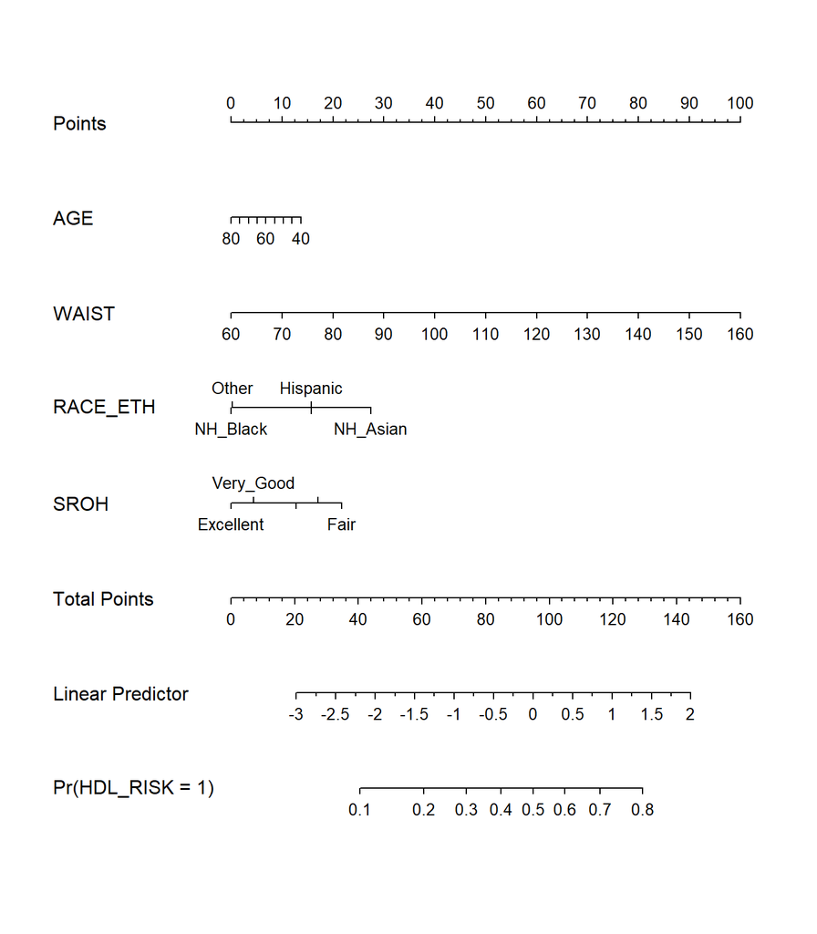

```r
plot(nomogram(mod_Y_lrm, fun = plogis,
              funlabel = "Pr(HDL_RISK = 1)"))
```

### 9.6.7 Predictions for Two New Subjects

I will create a predicted Pr(`HDL_RISK` = 1) for two new Non-Hispanic White subjects who are 60 years old, and who rate their overall health as Fair. The first will have a waist circumference of 80 cm, and the second will have a waist circumference of 100 cm.

**Note**

I can do this using either the `glm()` or the `lrm()` fit to our model. Either is sufficient for Project A, and there’s no need to show both approaches.

**Using the glm() fit**

```r
new_subj <-
  data.frame(AGE = c(60,60), WAIST = c(80, 100),
             RACE_ETH = c("NH_White", "NH_White"), SROH = c("Fair", "Fair"))

preds3 <- predict(mod_Y, newdata = new_subj, type = "response")

preds3
```

```
        1         2
0.2256724 0.3949595
```

- Our prediction for subject 1’s Pr(HDL_RISK = 1) is 0.226.
- Our prediction for subject 2’s Pr(HDL_RISK = 1) is 0.395.

**Using the lrm() fit**

Alternatively, I could have used our `lrm()` fit.

```r
new_subj <-
  data.frame(AGE = c(60,60), WAIST = c(80, 100),
             RACE_ETH = c("NH_White", "NH_White"), SROH = c("Fair", "Fair"))

preds4 <- predict(mod_Y_lrm, newdata = new_subj, type = "fitted")

preds4
```

```
        1         2
0.2256724 0.3949595
```

As before, the two fitting approaches (`glm()` and `lrm()`) produce the same model, so they produce the same predictions.

# 10 Discussion

**Note**

I am leaving the discussion up to you, but I have provided an outline of what you need to address below.

## 10.1 Answering My Research Questions

### 10.1.1 Question 1 (with Answer)

I’ll leave the job of restating and drawing conclusions about the research question under study in our linear regression analyses for you to answer.

### 10.1.2 Question 2 (with Answer)

I’ll leave the job of restating and drawing conclusions about the research question under study in our logistic regression analyses for you to answer.

## 10.2 Thoughts on Project A

Note that we expect you to answer exactly two of the following four questions in your discussion.

### 10.2.1 Question 1

> What was substantially harder or easier than you expected, and why?

If you chose to answer Question 1, your answer would go here.

### 10.2.2 Question 2

> What do you wish you’d known at the start of this process that you know now, and why?

If you chose to answer Question 2, your answer would go here.

### 10.2.3 Question 3

> What was the most confusing part of doing the project, and how did you get past it?

If you chose to answer Question 3, your answer would go here.

### 10.2.4 Question 4

> What was the most useful thing you learned while doing the project, and why?

If you chose to answer Question 4, your answer would go here.

# 11 Affirmation

I am certain that it is completely appropriate for these NHANES data to be shared with anyone, without any conditions. There are no concerns about privacy or security.

# 12 References

1. NHANES 2015-16 data are found at https://wwwn.cdc.gov/nchs/nhanes/continuousnhanes/default.aspx?BeginYear=2015.
2. NHANES 2017-18 data are found at https://wwwn.cdc.gov/nchs/nhanes/continuousnhanes/default.aspx?BeginYear=2017.
3. Descriptions/definitions of “at risk” levels of HDL cholesterol are provided by the Mayo Clinic at https://www.mayoclinic.org/diseases-conditions/high-blood-cholesterol/in-depth/hdl-cholesterol/art-20046388.